# Applied Statistics

## Part A

### 1. Please refer the table below to answer below questions: [2 Marks]

| Planned to purchase Product A | Actually placed order for Product A - Yes | Actually placed order for Product A - No | Total |
| --- | --- | --- | --- |
| Yes | 400 | 100 | 500 |
| No | 200 | 1300 | 1500 |
| Total | 600 | 1400 | 2000 |

#### 1.A. Refer above table and find the joint probability of the people who planned to purchase and actually placed an order. [1 Mark]

```python
import numpy as np
import pandas as pd
import scipy.stats as stats
import matplotlib.pyplot as plt
import seaborn as sns
```

```python
#From the table given,
#number of people who planned to purchase and actually placed an order = 400
#total number of people = 2000
#Probability(planned and purchased) can be calculated as
prob_planned_and_purchased=400/2000
print("Answer: Probability(planned and purchased) = {}".format(prob_planned_and_purchased))
```

```
Answer: Probability(planned and purchased) = 0.2
```

#### 1.B. Refer to the above table and find the joint probability of the people who planned to purchase and actually placed an order, given that people planned to purchase. [1 Mark]

```python
#From the table given,
#number of people who planned to purchase = 500
#number of people who planned to purchase and actually placed an order = 400
#total number of people = 2000

#Probability(planned and purchased) can be calculated as
prob_planned_and_purchased=400/2000
print("Probability(planned and purchased) = {}".format(prob_planned_and_purchased))

#Probability(planned) can be calculated as
prob_planned=500/2000
print("Probability(planned) = {}".format(prob_planned))

#Probability(planned and purchased GIVEN THAT planned) can be calculated as
prob_planned_and_purchased_given_planned=prob_planned_and_purchased/prob_planned
print("Answer: Probability(planned_and_purchased_given_planned) = {}".format(prob_planned_and_purchased_given_planned))
```

```
Probability(planned and purchased) = 0.2
Probability(planned) = 0.25
Answer: Probability(planned_and_purchased_given_planned) = 0.8
```

### 2. An electrical manufacturing company conducts quality checks at specified periods on the products it manufactures. Historically, the failure rate for the manufactured item is 5%. Suppose a random sample of 10 manufactured items is selected. Answer the following questions. [4 Marks]

#### 2.A. Probability that none of the items are defective? [1 Mark]

```python
#probability of failure item is 0.05
p=0.05

#random sample items
n=10

#probability of getting 0 defective items by applying binomial probability function
#P(x) = ⁿCₓpˣ(1-p)ⁿ⁻ˣ

x=0
#prob_0_defect=(np.math.factorial(10)/(np.math.factorial(0)*np.math.factorial(10-0)))*((0.05**0)*(0.95**10))

nCx=np.math.factorial(10)/(np.math.factorial(0)*np.math.factorial(10-0))
print("nCx = {}".format(nCx))

prob_0_defects=nCx*(0.05**0)*(0.95**10)

print("Answer: probability of getting zero defects = {}".format(prob_0_defects))
bino_0_pmf=stats.binom.pmf(x,n,p)
print("Answer: probability of getting zero defects using stats= {}".format(bino_0_pmf))
```

```
nCx = 1.0
Answer: probability of getting zero defects = 0.5987369392383787
Answer: probability of getting zero defects using stats= 0.5987369392383787
```

#### 2.B. Probability that exactly one of the items is defective? [1 Mark]

```python
#probability of failure item is 0.05
p=0.05

#random sample items
n=10

#probability of getting 0 defective items by applying binomial probability function
#P(x) = ⁿCₓpˣ(1-p)ⁿ⁻ˣ
x=1
#prob_1_defect=(np.math.factorial(10)/(np.math.factorial(1)*np.math.factorial(10-1)))*((0.05**1)*(0.95**9))

nCx=np.math.factorial(10)/(np.math.factorial(1)*np.math.factorial(10-1))
print("nCx = {}".format(nCx))

prob_1_defect=nCx*(0.05**1)*(0.95**9)

print("Answer: probability of getting 1 defect = {}".format(prob_1_defect))
bino_1_pmf=stats.binom.pmf(x,n,p)
print("Answer: probability of getting 1 defect using stats= {}".format(bino_1_pmf))
```

```
nCx = 10.0
Answer: probability of getting 1 defect = 0.31512470486230454
Answer: probability of getting 1 defect using stats= 0.3151247048623047
```

#### 2.C. Probability that two or fewer of the items are defective? [1 Mark]

```python
#probability of failure item is 0.05
p=0.05

#random sample items
n=10

#probability of getting 0 defective items by applying binomial probability function
#P(x) = ⁿCₓpˣ(1-p)ⁿ⁻ˣ
x=2
#prob_2_defects=(np.math.factorial(10)/(np.math.factorial(2)*np.math.factorial(10-2)))*((0.05**2)*(0.95**8))

nCx=np.math.factorial(10)/(np.math.factorial(2)*np.math.factorial(10-2))
print("nCx = {}".format(nCx))

prob_2_defects=nCx*(0.05**2)*(0.95**8)

print("probability of getting 2 defects = {}".format(prob_2_defects))
print("probability of getting 1 defect = {}".format(prob_1_defect))
print("probability of getting 0 defects = {}".format(prob_0_defects))
prob_2_or_fewer_defects=prob_0_defects+prob_1_defect+prob_2_defects
print("Answer: probability of getting 2 or fewer defects = {}".format(prob_2_or_fewer_defects))
bino_2_cdf=stats.binom.cdf(x,n,p)
print("Answer: probability of getting 2 or fewer defects using stats= {}".format(bino_2_cdf))
```

```
nCx = 45.0
probability of getting 2 defects = 0.07463479852001952
probability of getting 1 defect = 0.31512470486230454
probability of getting 0 defects = 0.5987369392383787
Answer: probability of getting 2 or fewer defects = 0.9884964426207028
Answer: probability of getting 2 or fewer defects using stats= 0.9884964426207031
```

#### 2.D. Probability that three or more of the items are defective ? [1 Mark]

```python
#probability of failure item is 0.05
p=0.05

#random sample items
n=10

#probability of getting 0 defective items by applying binomial probability function
#P(x) = ⁿCₓpˣ(1-p)ⁿ⁻ˣ
x=3

prob_3_or_more_defects=1 - (prob_0_defects+prob_1_defect+prob_2_defects)
print("Answer: probability of getting 3 or more defects = {}".format(prob_3_or_more_defects))
bino_3_or_more_cdf=1 - bino_2_cdf
print("Answer: probability of getting 3 or more defects using stats = {}".format(bino_3_or_more_cdf))
```

```
Answer: probability of getting 3 or more defects = 0.011503557379297202
Answer: probability of getting 3 or more defects using stats = 0.01150355737929687
```

### 3. A car salesman sells on an average 3 cars per week. [3 Marks]

#### 3.A. What is Probability that in a given week he will sell some cars? [1 Mark]

```python
rate=3
poisson_0_car=stats.poisson.pmf(0,rate)
print("probability of selling no cars = {}".format(poisson_0_car))
poisson_some_car=1-poisson_0_car
print("Answer: probability of selling some car using stats = {}".format(poisson_some_car))
```

```
probability of selling no cars = 0.049787068367863944
Answer: probability of selling some car using stats = 0.950212931632136
```

#### 3.B. What is Probability that in a given week he will sell 2 or more but less than 5 cars? [1 Mark]

```python
rate=3
poisson_2_cars=stats.poisson.pmf(2,rate)
poisson_3_cars=stats.poisson.pmf(3,rate)
poisson_4_cars=stats.poisson.pmf(4,rate)
print("probability of selling 2 cars = {}".format(poisson_2_cars))
print("probability of selling 3 cars = {}".format(poisson_3_cars))
print("probability of selling 4 cars = {}".format(poisson_4_cars))
poisson_2more_less5_car=poisson_2_cars+poisson_3_cars+poisson_4_cars
print("Answer: probability of selling 2 or more but less than 5 cars using stats = {}".format(poisson_2more_less5_car))
```

```
probability of selling 2 cars = 0.22404180765538775
probability of selling 3 cars = 0.22404180765538775
probability of selling 4 cars = 0.16803135574154085
Answer: probability of selling 2 or more but less than 5 cars using stats = 0.6161149710523164
```

#### 3.C. Plot the poisson distribution function for cumulative probability of cars sold per-week vs number of cars sold per week. [1 Mark]

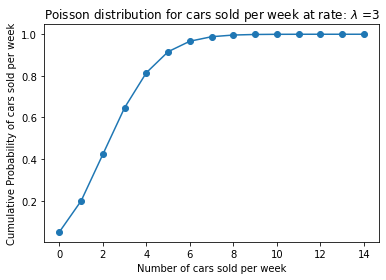

```python
rate=3
n=np.arange(0,15)
poisson_cdf=stats.poisson.cdf(n,rate)

plt.plot(n,poisson_cdf,'o-')
plt.title('Poisson distribution for cars sold per week at rate: $\lambda$ =%i' %rate)
plt.xlabel('Number of cars sold per week')
plt.ylabel('Cumulative Probability of cars sold per week')
```

### 4. Accuracy in understanding orders for a speech based bot at a restaurant is important for the Company X which has designed, marketed and launched the product for a contactless delivery due to the COVID-19 pandemic. Recognition accuracy that measures the percentage of orders that are taken correctly is 86.8%. Suppose that you place an order with the bot and two friends of yours independently place orders with the same bot. Answer the following questions. [3 Marks]

#### 4.A. What is the probability that all three orders will be recognised correctly? [1 Mark]

```python
p=0.868
n=3
x=3
prob_3_corr=stats.binom.pmf(x,n,p)
print("Answer: probability that all three orders will be recognised correctly = {}".format(prob_3_corr))
```

```
Answer: probability that all three orders will be recognised correctly = 0.653972032
```

#### 4.B. What is the probability that none of the three orders will be recognised correctly? [1 Mark]

```python
p=0.868
n=3
x=0
prob_0_corr=stats.binom.pmf(x,n,p)
print("Answer: probability that none of the three orders will be recognised correctly = {}".format(prob_0_corr))
```

```
Answer: probability that none of the three orders will be recognised correctly = 0.0022999680000000003
```

#### 4.C. What is the probability that at least two of the three orders will be recognised correctly? [1 Mark]

```python
p=0.868
n=3
prob_atleast2_corr=stats.binom.pmf(2,n,p)+stats.binom.pmf(3,n,p)
print("Answer: probability that at least two of the three orders will be recognised correctly = {}".format(prob_atleast2_corr))
```

```
Answer: probability that at least two of the three orders will be recognised correctly = 0.952327936
```

### 5. Explain 1 real life industry scenario (other than the ones mentioned above) where you can use the concepts learnt in this module of Applied Statistics to get data driven business solution. [3 Marks]

#### Answer:

#### Business scenario:

Bank xyz has a large Credit Card portfolio. Based on empirical data, they have found that 60% of the customers pay their bill on time. If a sample of 10 accounts is selected from the current database, construct the Probability Distribution of accounts paying on time.

```python
x=np.arange(0,11)
prob_pay_on_time=stats.binom.pmf(x,10,0.6)
print("Probability Distribution of accounts paying on time :\n{}".format(prob_pay_on_time))
```

```
Probability Distribution of accounts paying on time :
[1.04857600e-04 1.57286400e-03 1.06168320e-02 4.24673280e-02
 1.11476736e-01 2.00658125e-01 2.50822656e-01 2.14990848e-01
 1.20932352e-01 4.03107840e-02 6.04661760e-03]
```

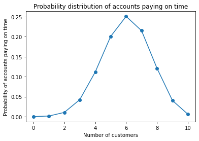

```python
plt.plot(x,prob_pay_on_time,'o-')
plt.title('Probability distribution of accounts paying on time')
plt.xlabel('Number of customers')
plt.ylabel('Probability of accounts paying on time')
```

# Part B

## PROJECT OBJECTIVE: Company’s management wants to invest on proposals on managing some of the best teams in the league. The analytics department has been assigned with a task of creating a report on the performance shown by the teams. Some of the older teams are already in contract with competitors. Hence Company X wants to understand which teams they can approach which will be a deal win for them.

### STEPS AND TASK [30 Marks]:

#### 1. Read the data set, clean the data and prepare final dataset to be used for analysis. [10 Marks]

```python
game=pd.read_csv("Basketball.csv")
game
```

|  | Team | Tournament | Score | PlayedGames | WonGames | DrawnGames | LostGames | BasketScored | BasketGiven | TournamentChampion | Runner-up | TeamLaunch | HighestPositionHeld |
| --- | --- | --- | --- | --- | --- | --- | --- | --- | --- | --- | --- | --- | --- |
| 0 | Team 1 | 86 | 4385 | 2762 | 1647 | 552 | 563 | 5947 | 3140 | 33 | 23 | 1929 | 1 |
| 1 | Team 2 | 86 | 4262 | 2762 | 1581 | 573 | 608 | 5900 | 3114 | 25 | 25 | 1929 | 1 |
| 2 | Team 3 | 80 | 3442 | 2614 | 1241 | 598 | 775 | 4534 | 3309 | 10 | 8 | 1929 | 1 |
| 3 | Team 4 | 82 | 3386 | 2664 | 1187 | 616 | 861 | 4398 | 3469 | 6 | 6 | 1931to32 | 1 |
| 4 | Team 5 | 86 | 3368 | 2762 | 1209 | 633 | 920 | 4631 | 3700 | 8 | 7 | 1929 | 1 |
| ... | ... | ... | ... | ... | ... | ... | ... | ... | ... | ... | ... | ... | ... |
| 56 | Team 57 | 1 | 34 | 38 | 8 | 10 | 20 | 38 | 66 | - | - | 2009-10 | 20 |
| 57 | Team 58 | 1 | 22 | 30 | 7 | 8 | 15 | 37 | 57 | - | - | 1956-57 | 16 |
| 58 | Team 59 | 1 | 19 | 30 | 7 | 5 | 18 | 51 | 85 | - | - | 1951~52 | 16 |
| 59 | Team 60 | 1 | 14 | 30 | 5 | 4 | 21 | 34 | 65 | - | - | 1955-56 | 15 |
| 60 | Team 61 | 1 | - | - | - | - | - | - | - | - | - | 2017~18 | 9 |

61 rows × 13 columns

From sample data above, we see some values of 'TournamentChampion','Runner-up' are '-', which is a non-numeric value. Also row 60, Team 61 - has most of the columns with value '-'.

```python
game.info()
```

```
<class 'pandas.core.frame.DataFrame'>
RangeIndex: 61 entries, 0 to 60
Data columns (total 13 columns):
 #   Column               Non-Null Count  Dtype
---  ------               --------------  -----
 0   Team                 61 non-null     object
 1   Tournament           61 non-null     int64
 2   Score                61 non-null     object
 3   PlayedGames          61 non-null     object
 4   WonGames             61 non-null     object
 5   DrawnGames           61 non-null     object
 6   LostGames            61 non-null     object
 7   BasketScored         61 non-null     object
 8   BasketGiven          61 non-null     object
 9   TournamentChampion   61 non-null     object
 10  Runner-up            61 non-null     object
 11  TeamLaunch           61 non-null     object
 12  HighestPositionHeld  61 non-null     int64
dtypes: int64(2), object(11)
memory usage: 6.3+ KB
```

##### Inference:

- Totally we have 61 entries and all the fields show non-null count as 61. So there are no null values in the dataset.
- From the sample data, except fields Team and TeamLaunch, all other fields seems to have numerical data - integers. These fields are holding counts, example - number of tournaments held, number of played games, number of won games etc. However the info() shows data type shows data type as object instead of int64. So we can infer that these fields hold some non-numerical data.  
  Let us try to find out the anomalies in the below steps.

```python
game.describe()
```

|  | Tournament | HighestPositionHeld |
| --- | --- | --- |
| count | 61.000000 | 61.000000 |
| mean | 24.000000 | 7.081967 |
| std | 26.827225 | 5.276663 |
| min | 1.000000 | 1.000000 |
| 25% | 4.000000 | 3.000000 |
| 50% | 12.000000 | 6.000000 |
| 75% | 38.000000 | 10.000000 |
| max | 86.000000 | 20.000000 |

```python
#quick check to see the non-numeric values
game.min()
```

```
Team                   Team 1
Tournament                  1
Score                       -
PlayedGames                 -
WonGames                    -
DrawnGames                  -
LostGames                   -
BasketScored                -
BasketGiven                 -
TournamentChampion          -
Runner-up                   -
TeamLaunch               1929
HighestPositionHeld         1
dtype: object
```

##### Inference:

min() will show minimum values for each column. We can see value '-' being the minimum value for most of the columns.

```python
#Apart from non-numeric values let us thoroughly check if there are null values

def null_check(df):
    total = df.isnull().sum().sort_values(ascending=False)   # total number of null values
    percent = (df.isnull().sum()/df.isnull().count()).sort_values(ascending=False)  # percentage of values that are null
    missing_data = pd.concat([total, percent], axis=1, keys=['Total', 'Percent'])  # putting the above two together
    return missing_data # return the dataframe
null_check(game)
```

|  | Total | Percent |
| --- | --- | --- |
| Team | 0 | 0.0 |
| Tournament | 0 | 0.0 |
| Score | 0 | 0.0 |
| PlayedGames | 0 | 0.0 |
| WonGames | 0 | 0.0 |
| DrawnGames | 0 | 0.0 |
| LostGames | 0 | 0.0 |
| BasketScored | 0 | 0.0 |
| BasketGiven | 0 | 0.0 |
| TournamentChampion | 0 | 0.0 |
| Runner-up | 0 | 0.0 |
| TeamLaunch | 0 | 0.0 |
| HighestPositionHeld | 0 | 0.0 |

##### Inference:

The above report shows no null values in any of the columns.

```python
#Now we can convert all types of non-numeric values to a single value - null value
#columns which have non-numeric values but expected to have numeric value
data_columns=['Score','PlayedGames','WonGames','DrawnGames','LostGames','BasketScored','BasketGiven','TournamentChampion','Runner-up']
game_final=game.drop(data_columns, axis=1).join(game[data_columns].apply(pd.to_numeric, errors='coerce'))
game_final
```

|  | Team | Tournament | TeamLaunch | HighestPositionHeld | Score | PlayedGames | WonGames | DrawnGames | LostGames | BasketScored | BasketGiven | TournamentChampion | Runner-up |
| --- | --- | --- | --- | --- | --- | --- | --- | --- | --- | --- | --- | --- | --- |
| 0 | Team 1 | 86 | 1929 | 1 | 4385.0 | 2762.0 | 1647.0 | 552.0 | 563.0 | 5947.0 | 3140.0 | 33.0 | 23.0 |
| 1 | Team 2 | 86 | 1929 | 1 | 4262.0 | 2762.0 | 1581.0 | 573.0 | 608.0 | 5900.0 | 3114.0 | 25.0 | 25.0 |
| 2 | Team 3 | 80 | 1929 | 1 | 3442.0 | 2614.0 | 1241.0 | 598.0 | 775.0 | 4534.0 | 3309.0 | 10.0 | 8.0 |
| 3 | Team 4 | 82 | 1931to32 | 1 | 3386.0 | 2664.0 | 1187.0 | 616.0 | 861.0 | 4398.0 | 3469.0 | 6.0 | 6.0 |
| 4 | Team 5 | 86 | 1929 | 1 | 3368.0 | 2762.0 | 1209.0 | 633.0 | 920.0 | 4631.0 | 3700.0 | 8.0 | 7.0 |
| ... | ... | ... | ... | ... | ... | ... | ... | ... | ... | ... | ... | ... | ... |
| 56 | Team 57 | 1 | 2009-10 | 20 | 34.0 | 38.0 | 8.0 | 10.0 | 20.0 | 38.0 | 66.0 | NaN | NaN |
| 57 | Team 58 | 1 | 1956-57 | 16 | 22.0 | 30.0 | 7.0 | 8.0 | 15.0 | 37.0 | 57.0 | NaN | NaN |
| 58 | Team 59 | 1 | 1951~52 | 16 | 19.0 | 30.0 | 7.0 | 5.0 | 18.0 | 51.0 | 85.0 | NaN | NaN |
| 59 | Team 60 | 1 | 1955-56 | 15 | 14.0 | 30.0 | 5.0 | 4.0 | 21.0 | 34.0 | 65.0 | NaN | NaN |
| 60 | Team 61 | 1 | 2017~18 | 9 | NaN | NaN | NaN | NaN | NaN | NaN | NaN | NaN | NaN |

61 rows × 13 columns

##### Inference:

The above result shows that all types of non-numeric values are converted to NaN (which is null value). game_final is the dataframe which has the converted values.

```python
#We can now convert the NaN to 0. As the fields are holding the counts 0 will be an appropriate value in this case.
game_final.fillna(0,inplace=True)
game_final[data_columns]=game_final[data_columns].apply(np.int64)
game_final
```

|  | Team | Tournament | TeamLaunch | HighestPositionHeld | Score | PlayedGames | WonGames | DrawnGames | LostGames | BasketScored | BasketGiven | TournamentChampion | Runner-up |
| --- | --- | --- | --- | --- | --- | --- | --- | --- | --- | --- | --- | --- | --- |
| 0 | Team 1 | 86 | 1929 | 1 | 4385 | 2762 | 1647 | 552 | 563 | 5947 | 3140 | 33 | 23 |
| 1 | Team 2 | 86 | 1929 | 1 | 4262 | 2762 | 1581 | 573 | 608 | 5900 | 3114 | 25 | 25 |
| 2 | Team 3 | 80 | 1929 | 1 | 3442 | 2614 | 1241 | 598 | 775 | 4534 | 3309 | 10 | 8 |
| 3 | Team 4 | 82 | 1931to32 | 1 | 3386 | 2664 | 1187 | 616 | 861 | 4398 | 3469 | 6 | 6 |
| 4 | Team 5 | 86 | 1929 | 1 | 3368 | 2762 | 1209 | 633 | 920 | 4631 | 3700 | 8 | 7 |
| ... | ... | ... | ... | ... | ... | ... | ... | ... | ... | ... | ... | ... | ... |
| 56 | Team 57 | 1 | 2009-10 | 20 | 34 | 38 | 8 | 10 | 20 | 38 | 66 | 0 | 0 |
| 57 | Team 58 | 1 | 1956-57 | 16 | 22 | 30 | 7 | 8 | 15 | 37 | 57 | 0 | 0 |
| 58 | Team 59 | 1 | 1951~52 | 16 | 19 | 30 | 7 | 5 | 18 | 51 | 85 | 0 | 0 |
| 59 | Team 60 | 1 | 1955-56 | 15 | 14 | 30 | 5 | 4 | 21 | 34 | 65 | 0 | 0 |
| 60 | Team 61 | 1 | 2017~18 | 9 | 0 | 0 | 0 | 0 | 0 | 0 | 0 | 0 | 0 |

61 rows × 13 columns

```python
# Duplicate check
dupes=game_final.duplicated()
sum(dupes)
```

```
0
```

##### Inference:

There are no duplictae records in the dataframe. So game_final is good to proceed for further processing.

```python
game_final.describe()
```

|  | Tournament | HighestPositionHeld | Score | PlayedGames | WonGames | DrawnGames | LostGames | BasketScored | BasketGiven | TournamentChampion | Runner-up |
| --- | --- | --- | --- | --- | --- | --- | --- | --- | --- | --- | --- |
| count | 61.000000 | 61.000000 | 61.000000 | 61.000000 | 61.000000 | 61.000000 | 61.000000 | 61.000000 | 61.000000 | 61.000000 | 61.000000 |
| mean | 24.000000 | 7.081967 | 901.426230 | 796.819672 | 303.967213 | 188.934426 | 303.754098 | 1140.344262 | 1140.229508 | 1.426230 | 1.409836 |
| std | 26.827225 | 5.276663 | 1134.899121 | 876.282765 | 406.991030 | 201.799477 | 294.708594 | 1506.740211 | 1163.710766 | 5.472535 | 4.540107 |
| min | 1.000000 | 1.000000 | 0.000000 | 0.000000 | 0.000000 | 0.000000 | 0.000000 | 0.000000 | 0.000000 | 0.000000 | 0.000000 |
| 25% | 4.000000 | 3.000000 | 96.000000 | 114.000000 | 34.000000 | 24.000000 | 62.000000 | 153.000000 | 221.000000 | 0.000000 | 0.000000 |
| 50% | 12.000000 | 6.000000 | 375.000000 | 423.000000 | 123.000000 | 95.000000 | 197.000000 | 430.000000 | 632.000000 | 0.000000 | 0.000000 |
| 75% | 38.000000 | 10.000000 | 1351.000000 | 1318.000000 | 426.000000 | 330.000000 | 563.000000 | 1642.000000 | 1951.000000 | 0.000000 | 0.000000 |
| max | 86.000000 | 20.000000 | 4385.000000 | 2762.000000 | 1647.000000 | 633.000000 | 1070.000000 | 5947.000000 | 3889.000000 | 33.000000 | 25.000000 |

```python
game_final.info()
```

```
<class 'pandas.core.frame.DataFrame'>
RangeIndex: 61 entries, 0 to 60
Data columns (total 13 columns):
 #   Column               Non-Null Count  Dtype
---  ------               --------------  -----
 0   Team                 61 non-null     object
 1   Tournament           61 non-null     int64
 2   TeamLaunch           61 non-null     object
 3   HighestPositionHeld  61 non-null     int64
 4   Score                61 non-null     int64
 5   PlayedGames          61 non-null     int64
 6   WonGames             61 non-null     int64
 7   DrawnGames           61 non-null     int64
 8   LostGames            61 non-null     int64
 9   BasketScored         61 non-null     int64
 10  BasketGiven          61 non-null     int64
 11  TournamentChampion   61 non-null     int64
 12  Runner-up            61 non-null     int64
dtypes: int64(11), object(2)
memory usage: 6.3+ KB
```

```python
game_final.head()
```

|  | Team | Tournament | TeamLaunch | HighestPositionHeld | Score | PlayedGames | WonGames | DrawnGames | LostGames | BasketScored | BasketGiven | TournamentChampion | Runner-up |
| --- | --- | --- | --- | --- | --- | --- | --- | --- | --- | --- | --- | --- | --- |
| 0 | Team 1 | 86 | 1929 | 1 | 4385 | 2762 | 1647 | 552 | 563 | 5947 | 3140 | 33 | 23 |
| 1 | Team 2 | 86 | 1929 | 1 | 4262 | 2762 | 1581 | 573 | 608 | 5900 | 3114 | 25 | 25 |
| 2 | Team 3 | 80 | 1929 | 1 | 3442 | 2614 | 1241 | 598 | 775 | 4534 | 3309 | 10 | 8 |
| 3 | Team 4 | 82 | 1931to32 | 1 | 3386 | 2664 | 1187 | 616 | 861 | 4398 | 3469 | 6 | 6 |
| 4 | Team 5 | 86 | 1929 | 1 | 3368 | 2762 | 1209 | 633 | 920 | 4631 | 3700 | 8 | 7 |

```python
game_final.tail()
```

|  | Team | Tournament | TeamLaunch | HighestPositionHeld | Score | PlayedGames | WonGames | DrawnGames | LostGames | BasketScored | BasketGiven | TournamentChampion | Runner-up |
| --- | --- | --- | --- | --- | --- | --- | --- | --- | --- | --- | --- | --- | --- |
| 56 | Team 57 | 1 | 2009-10 | 20 | 34 | 38 | 8 | 10 | 20 | 38 | 66 | 0 | 0 |
| 57 | Team 58 | 1 | 1956-57 | 16 | 22 | 30 | 7 | 8 | 15 | 37 | 57 | 0 | 0 |
| 58 | Team 59 | 1 | 1951~52 | 16 | 19 | 30 | 7 | 5 | 18 | 51 | 85 | 0 | 0 |
| 59 | Team 60 | 1 | 1955-56 | 15 | 14 | 30 | 5 | 4 | 21 | 34 | 65 | 0 | 0 |
| 60 | Team 61 | 1 | 2017~18 | 9 | 0 | 0 | 0 | 0 | 0 | 0 | 0 | 0 | 0 |

When investigating the bottom records of the dataset, Team61 has not played any games however the HighestPositionHeld is 9. This means Team61 should have played some games which is contradicting to the PlayedGames value. This record has to be ignored as it has missing values. This is incomplete data. We can drop this record.

```python
game_final.drop(60,inplace=True)
game_final.shape
```

```
(60, 13)
```

This is the final dataset after cleaning up the anomalies.

#### 2. Perform detailed statistical analysis and EDA using univariate, bi-variate and multivariate EDA techniques to get data driven insights on recommending which teams they can approach which will be a deal win for them. Also as a data and statistics expert you have to develop a detailed performance report using this data. [10 Marks]

##### Additional Features:

- WinRate: Number of games won to number of games played.
- LossRate: Number of games lost to number of games played.
- BasketScoreRate: Number of baskets scored to number of basket given
- ChampionRate: Number of winning the championship to number of tournaments played

Create one other field TeamLaunchYear to hold the year on which the team was launched. In order to perform some statistic on this field, set the data type to integer.

```python
game_final['WinRate']=round((game_final.WonGames/game_final.PlayedGames)*100,2)
game_final['LossRate']=round((game_final.LostGames/game_final.PlayedGames)*100,2)
game_final['DrawnRate']=round((game_final.DrawnGames/game_final.PlayedGames)*100,2)
game_final['BasketScoreRate']=round((game_final.BasketScored/game_final.BasketGiven)*100,2)
game_final['ChampionRate']=round((game_final.TournamentChampion/game_final.Tournament)*100,2)
game_final['TeamLaunchYear']=game_final.TeamLaunch.str[:4]
game_final['TeamLaunchYear']=game_final['TeamLaunchYear'].astype('int64')
game_final
```

|  | Team | Tournament | TeamLaunch | HighestPositionHeld | Score | PlayedGames | WonGames | DrawnGames | LostGames | BasketScored | BasketGiven | TournamentChampion | Runner-up | WinRate | LossRate | DrawnRate | BasketScoreRate | ChampionRate | TeamLaunchYear |
| --- | --- | --- | --- | --- | --- | --- | --- | --- | --- | --- | --- | --- | --- | --- | --- | --- | --- | --- | --- |
| 0 | Team 1 | 86 | 1929 | 1 | 4385 | 2762 | 1647 | 552 | 563 | 5947 | 3140 | 33 | 23 | 59.63 | 20.38 | 19.99 | 189.39 | 38.37 | 1929 |
| 1 | Team 2 | 86 | 1929 | 1 | 4262 | 2762 | 1581 | 573 | 608 | 5900 | 3114 | 25 | 25 | 57.24 | 22.01 | 20.75 | 189.47 | 29.07 | 1929 |
| 2 | Team 3 | 80 | 1929 | 1 | 3442 | 2614 | 1241 | 598 | 775 | 4534 | 3309 | 10 | 8 | 47.48 | 29.65 | 22.88 | 137.02 | 12.50 | 1929 |
| 3 | Team 4 | 82 | 1931to32 | 1 | 3386 | 2664 | 1187 | 616 | 861 | 4398 | 3469 | 6 | 6 | 44.56 | 32.32 | 23.12 | 126.78 | 7.32 | 1931 |
| 4 | Team 5 | 86 | 1929 | 1 | 3368 | 2762 | 1209 | 633 | 920 | 4631 | 3700 | 8 | 7 | 43.77 | 33.31 | 22.92 | 125.16 | 9.30 | 1929 |
| 5 | Team 6 | 73 | 1934-35 | 1 | 2819 | 2408 | 990 | 531 | 887 | 3680 | 3373 | 1 | 4 | 41.11 | 36.84 | 22.05 | 109.10 | 1.37 | 1934 |
| 6 | Team 7 | 82 | 1929 | 3 | 2792 | 2626 | 948 | 608 | 1070 | 3609 | 3889 | 0 | 0 | 36.10 | 40.75 | 23.15 | 92.80 | 0.00 | 1929 |
| 7 | Team 8 | 70 | 1929 | 1 | 2573 | 2302 | 864 | 577 | 861 | 3228 | 3230 | 2 | 3 | 37.53 | 37.40 | 25.07 | 99.94 | 2.86 | 1929 |
| 8 | Team 9 | 58 | 1939-40 | 2 | 2109 | 1986 | 698 | 522 | 766 | 2683 | 2847 | 0 | 1 | 35.15 | 38.57 | 26.28 | 94.24 | 0.00 | 1939 |
| 9 | Team 10 | 51 | 1932-33 | 1 | 1884 | 1728 | 606 | 440 | 682 | 2159 | 2492 | 1 | 0 | 35.07 | 39.47 | 25.46 | 86.64 | 1.96 | 1932 |
| 10 | Team 11 | 45 | 1941to42 | 1 | 1814 | 1530 | 563 | 392 | 575 | 2052 | 2188 | 1 | 5 | 36.80 | 37.58 | 25.62 | 93.78 | 2.22 | 1941 |
| 11 | Team 12 | 51 | 1939-40 | 4 | 1789 | 1698 | 586 | 389 | 723 | 2278 | 2624 | 0 | 0 | 34.51 | 42.58 | 22.91 | 86.81 | 0.00 | 1939 |
| 12 | Team 13 | 42 | 1948-49 | 4 | 1471 | 1466 | 463 | 384 | 619 | 1767 | 2180 | 0 | 0 | 31.58 | 42.22 | 26.19 | 81.06 | 0.00 | 1948 |
| 13 | Team 14 | 44 | 1929 | 2 | 1416 | 1428 | 453 | 336 | 639 | 1843 | 2368 | 0 | 1 | 31.72 | 44.75 | 23.53 | 77.83 | 0.00 | 1929 |
| 14 | Team 15 | 43 | 1944_45 | 2 | 1389 | 1458 | 471 | 358 | 629 | 1753 | 2152 | 0 | 1 | 32.30 | 43.14 | 24.55 | 81.46 | 0.00 | 1944 |
| 15 | Team 16 | 37 | 1935-36 | 4 | 1351 | 1318 | 426 | 327 | 565 | 1500 | 1834 | 0 | 0 | 32.32 | 42.87 | 24.81 | 81.79 | 0.00 | 1935 |
| 16 | Team 17 | 36 | 1949_50 | 4 | 1314 | 1255 | 390 | 330 | 535 | 1421 | 1763 | 0 | 0 | 31.08 | 42.63 | 26.29 | 80.60 | 0.00 | 1949 |
| 17 | Team 18 | 38 | 1933to34 | 3 | 1174 | 1192 | 408 | 292 | 492 | 1642 | 1951 | 0 | 0 | 34.23 | 41.28 | 24.50 | 84.16 | 0.00 | 1933 |
| 18 | Team 19 | 27 | 1960-61 | 3 | 1148 | 988 | 333 | 256 | 399 | 1182 | 1371 | 0 | 0 | 33.70 | 40.38 | 25.91 | 86.21 | 0.00 | 1960 |
| 19 | Team 20 | 33 | 1951-52 | 2 | 1020 | 1096 | 367 | 242 | 487 | 1347 | 1746 | 0 | 1 | 33.49 | 44.43 | 22.08 | 77.15 | 0.00 | 1951 |
| 20 | Team 21 | 17 | 1998-99 | 2 | 970 | 646 | 266 | 172 | 208 | 892 | 789 | 0 | 1 | 41.18 | 32.20 | 26.63 | 113.05 | 0.00 | 1998 |
| 21 | Team 22 | 23 | 1941-42 | 6 | 667 | 742 | 218 | 175 | 349 | 819 | 1157 | 0 | 0 | 29.38 | 47.04 | 23.58 | 70.79 | 0.00 | 1941 |
| 22 | Team 23 | 17 | 1977-78 | 8 | 662 | 652 | 189 | 148 | 305 | 760 | 1088 | 0 | 0 | 28.99 | 46.78 | 22.70 | 69.85 | 0.00 | 1977 |
| 23 | Team 24 | 21 | 1959-60 | 5 | 606 | 678 | 203 | 180 | 295 | 750 | 1022 | 0 | 0 | 29.94 | 43.51 | 26.55 | 73.39 | 0.00 | 1959 |
| 24 | Team 25 | 12 | 2004to05 | 6 | 553 | 456 | 147 | 112 | 197 | 520 | 633 | 0 | 0 | 32.24 | 43.20 | 24.56 | 82.15 | 0.00 | 2004 |
| 25 | Team 26 | 20 | 1935-36 | 5 | 538 | 628 | 184 | 149 | 295 | 716 | 1050 | 0 | 0 | 29.30 | 46.97 | 23.73 | 68.19 | 0.00 | 1935 |
| 26 | Team 27 | 13 | 1961-62 | 5 | 510 | 494 | 155 | 128 | 211 | 619 | 744 | 0 | 0 | 31.38 | 42.71 | 25.91 | 83.20 | 0.00 | 1961 |
| 27 | Team 28 | 18 | 1940-41 | 11 | 445 | 586 | 145 | 143 | 298 | 607 | 992 | 0 | 0 | 24.74 | 50.85 | 24.40 | 61.19 | 0.00 | 1940 |
| 28 | Team 29 | 12 | 1930-31 | 6 | 421 | 380 | 125 | 81 | 174 | 458 | 623 | 0 | 0 | 32.89 | 45.79 | 21.32 | 73.52 | 0.00 | 1930 |
| 29 | Team 30 | 11 | 1963-64 | 6 | 416 | 402 | 113 | 95 | 194 | 430 | 632 | 0 | 0 | 28.11 | 48.26 | 23.63 | 68.04 | 0.00 | 1963 |
| 30 | Team 31 | 12 | 1974-75 | 7 | 375 | 423 | 123 | 102 | 198 | 422 | 581 | 0 | 0 | 29.08 | 46.81 | 24.11 | 72.63 | 0.00 | 1974 |
| 31 | Team 32 | 14 | 1943-44 | 4 | 353 | 426 | 129 | 95 | 202 | 492 | 720 | 0 | 0 | 30.28 | 47.42 | 22.30 | 68.33 | 0.00 | 1943 |
| 32 | Team 33 | 12 | 1977-78 | 12 | 343 | 448 | 104 | 127 | 217 | 393 | 662 | 0 | 0 | 23.21 | 48.44 | 28.35 | 59.37 | 0.00 | 1977 |
| 33 | Team 34 | 9 | 1987-88 | 7 | 293 | 346 | 96 | 92 | 158 | 291 | 489 | 0 | 0 | 27.75 | 45.66 | 26.59 | 59.51 | 0.00 | 1987 |
| 34 | Team 35 | 11 | 1941-42 | 4 | 285 | 334 | 103 | 79 | 152 | 419 | 588 | 0 | 0 | 30.84 | 45.51 | 23.65 | 71.26 | 0.00 | 1941 |
| 35 | Team 36 | 7 | 1991_92 | 7 | 277 | 270 | 76 | 76 | 118 | 320 | 410 | 0 | 0 | 28.15 | 43.70 | 28.15 | 78.05 | 0.00 | 1991 |
| 36 | Team 37 | 6 | 2007-08 | 8 | 242 | 228 | 62 | 56 | 110 | 244 | 366 | 0 | 0 | 27.19 | 48.25 | 24.56 | 66.67 | 0.00 | 2007 |
| 37 | Team 38 | 9 | 1962-63 | 5 | 230 | 282 | 82 | 63 | 137 | 285 | 430 | 0 | 0 | 29.08 | 48.58 | 22.34 | 66.28 | 0.00 | 1962 |
| 38 | Team 39 | 4 | 1994-95 | 10 | 190 | 160 | 52 | 45 | 63 | 199 | 241 | 0 | 0 | 32.50 | 39.38 | 28.12 | 82.57 | 0.00 | 1994 |
| 39 | Team 40 | 5 | 1978-79 | 8 | 188 | 186 | 50 | 46 | 90 | 202 | 296 | 0 | 0 | 26.88 | 48.39 | 24.73 | 68.24 | 0.00 | 1978 |
| 40 | Team 41 | 6 | 1971-72 | 12 | 168 | 204 | 59 | 50 | 95 | 216 | 310 | 0 | 0 | 28.92 | 46.57 | 24.51 | 69.68 | 0.00 | 1971 |
| 41 | Team 42 | 6 | 1963-64 | 7 | 150 | 180 | 53 | 44 | 83 | 165 | 221 | 0 | 0 | 29.44 | 46.11 | 24.44 | 74.66 | 0.00 | 1963 |
| 42 | Team 43 | 4 | 1999to00 | 17 | 148 | 152 | 37 | 37 | 78 | 155 | 253 | 0 | 0 | 24.34 | 51.32 | 24.34 | 61.26 | 0.00 | 1999 |
| 43 | Team 44 | 3 | 2014-15 | 10 | 132 | 114 | 35 | 27 | 52 | 139 | 167 | 0 | 0 | 30.70 | 45.61 | 23.68 | 83.23 | 0.00 | 2014 |
| 44 | Team 45 | 7 | 1929 | 3 | 107 | 130 | 43 | 21 | 66 | 227 | 308 | 0 | 0 | 33.08 | 50.77 | 16.15 | 73.70 | 0.00 | 1929 |
| 45 | Team 46 | 3 | 1990-91 | 9 | 96 | 114 | 26 | 44 | 44 | 101 | 139 | 0 | 0 | 22.81 | 38.60 | 38.60 | 72.66 | 0.00 | 1990 |
| 46 | Team 47 | 4 | 1947-48 | 7 | 91 | 116 | 34 | 16 | 66 | 181 | 295 | 0 | 0 | 29.31 | 56.90 | 13.79 | 61.36 | 0.00 | 1947 |
| 47 | Team 48 | 2 | 1996-97 | 17 | 83 | 80 | 20 | 23 | 37 | 62 | 117 | 0 | 0 | 25.00 | 46.25 | 28.75 | 52.99 | 0.00 | 1996 |
| 48 | Team 49 | 2 | 1995-96 | 19 | 81 | 80 | 19 | 24 | 37 | 70 | 115 | 0 | 0 | 23.75 | 46.25 | 30.00 | 60.87 | 0.00 | 1995 |
| 49 | Team 50 | 4 | 1945-46 | 10 | 76 | 108 | 30 | 16 | 62 | 145 | 252 | 0 | 0 | 27.78 | 57.41 | 14.81 | 57.54 | 0.00 | 1945 |
| 50 | Team 51 | 3 | 1953-54 | 14 | 71 | 90 | 29 | 13 | 48 | 121 | 183 | 0 | 0 | 32.22 | 53.33 | 14.44 | 66.12 | 0.00 | 1953 |
| 51 | Team 52 | 4 | 1929 | 6 | 56 | 72 | 21 | 14 | 37 | 153 | 184 | 0 | 0 | 29.17 | 51.39 | 19.44 | 83.15 | 0.00 | 1929 |
| 52 | Team 53 | 2 | 1979-80 | 10 | 52 | 68 | 17 | 18 | 33 | 71 | 116 | 0 | 0 | 25.00 | 48.53 | 26.47 | 61.21 | 0.00 | 1979 |
| 53 | Team 54 | 3 | 1929 | 8 | 42 | 54 | 18 | 6 | 30 | 97 | 131 | 0 | 0 | 33.33 | 55.56 | 11.11 | 74.05 | 0.00 | 1929 |
| 54 | Team 55 | 2 | 1950-51 | 16 | 40 | 68 | 13 | 14 | 41 | 70 | 182 | 0 | 0 | 19.12 | 60.29 | 20.59 | 38.46 | 0.00 | 1950 |
| 55 | Team 56 | 1 | 2016_17 | 17 | 35 | 38 | 8 | 11 | 19 | 36 | 55 | 0 | 0 | 21.05 | 50.00 | 28.95 | 65.45 | 0.00 | 2016 |
| 56 | Team 57 | 1 | 2009-10 | 20 | 34 | 38 | 8 | 10 | 20 | 38 | 66 | 0 | 0 | 21.05 | 52.63 | 26.32 | 57.58 | 0.00 | 2009 |
| 57 | Team 58 | 1 | 1956-57 | 16 | 22 | 30 | 7 | 8 | 15 | 37 | 57 | 0 | 0 | 23.33 | 50.00 | 26.67 | 64.91 | 0.00 | 1956 |
| 58 | Team 59 | 1 | 1951~52 | 16 | 19 | 30 | 7 | 5 | 18 | 51 | 85 | 0 | 0 | 23.33 | 60.00 | 16.67 | 60.00 | 0.00 | 1951 |
| 59 | Team 60 | 1 | 1955-56 | 15 | 14 | 30 | 5 | 4 | 21 | 34 | 65 | 0 | 0 | 16.67 | 70.00 | 13.33 | 52.31 | 0.00 | 1955 |

```python
game_final.head()
```

|  | Team | Tournament | TeamLaunch | HighestPositionHeld | Score | PlayedGames | WonGames | DrawnGames | LostGames | BasketScored | BasketGiven | TournamentChampion | Runner-up | WinRate | LossRate | DrawnRate | BasketScoreRate | ChampionRate | TeamLaunchYear |
| --- | --- | --- | --- | --- | --- | --- | --- | --- | --- | --- | --- | --- | --- | --- | --- | --- | --- | --- | --- |
| 0 | Team 1 | 86 | 1929 | 1 | 4385 | 2762 | 1647 | 552 | 563 | 5947 | 3140 | 33 | 23 | 59.63 | 20.38 | 19.99 | 189.39 | 38.37 | 1929 |
| 1 | Team 2 | 86 | 1929 | 1 | 4262 | 2762 | 1581 | 573 | 608 | 5900 | 3114 | 25 | 25 | 57.24 | 22.01 | 20.75 | 189.47 | 29.07 | 1929 |
| 2 | Team 3 | 80 | 1929 | 1 | 3442 | 2614 | 1241 | 598 | 775 | 4534 | 3309 | 10 | 8 | 47.48 | 29.65 | 22.88 | 137.02 | 12.50 | 1929 |
| 3 | Team 4 | 82 | 1931to32 | 1 | 3386 | 2664 | 1187 | 616 | 861 | 4398 | 3469 | 6 | 6 | 44.56 | 32.32 | 23.12 | 126.78 | 7.32 | 1931 |
| 4 | Team 5 | 86 | 1929 | 1 | 3368 | 2762 | 1209 | 633 | 920 | 4631 | 3700 | 8 | 7 | 43.77 | 33.31 | 22.92 | 125.16 | 9.30 | 1929 |

```python
game_final.describe()
```

|  | Tournament | HighestPositionHeld | Score | PlayedGames | WonGames | DrawnGames | LostGames | BasketScored | BasketGiven | TournamentChampion | Runner-up | WinRate | LossRate | DrawnRate | BasketScoreRate | ChampionRate | TeamLaunchYear |
| --- | --- | --- | --- | --- | --- | --- | --- | --- | --- | --- | --- | --- | --- | --- | --- | --- | --- |
| count | 60.000000 | 60.000000 | 60.000000 | 60.000000 | 60.000000 | 60.000000 | 60.000000 | 60.000000 | 60.000000 | 60.00000 | 60.000000 | 60.000000 | 60.000000 | 60.000000 | 60.000000 | 60.000000 | 60.000000 |
| mean | 24.383333 | 7.050000 | 916.450000 | 810.100000 | 309.033333 | 192.083333 | 308.816667 | 1159.350000 | 1159.233333 | 1.45000 | 1.433333 | 31.364667 | 44.992167 | 23.617167 | 80.481000 | 1.749500 | 1957.950000 |
| std | 26.884620 | 5.315232 | 1138.342899 | 877.465393 | 408.481395 | 201.985508 | 294.508639 | 1512.063948 | 1163.946914 | 5.51554 | 4.574679 | 7.831421 | 8.401111 | 4.459405 | 27.305231 | 6.442478 | 26.646732 |
| min | 1.000000 | 1.000000 | 14.000000 | 30.000000 | 5.000000 | 4.000000 | 15.000000 | 34.000000 | 55.000000 | 0.00000 | 0.000000 | 16.670000 | 20.380000 | 11.110000 | 38.460000 | 0.000000 | 1929.000000 |
| 25% | 4.000000 | 3.000000 | 104.250000 | 115.500000 | 34.750000 | 26.250000 | 62.750000 | 154.500000 | 236.000000 | 0.00000 | 0.000000 | 27.610000 | 41.147500 | 22.330000 | 65.952500 | 0.000000 | 1934.750000 |
| 50% | 12.000000 | 6.000000 | 395.500000 | 424.500000 | 124.000000 | 98.500000 | 197.500000 | 444.000000 | 632.500000 | 0.00000 | 0.000000 | 30.490000 | 45.725000 | 24.370000 | 73.610000 | 0.000000 | 1950.500000 |
| 75% | 39.000000 | 10.000000 | 1360.500000 | 1345.500000 | 432.750000 | 331.500000 | 563.500000 | 1669.750000 | 2001.250000 | 0.00000 | 0.000000 | 33.542500 | 48.542500 | 26.212500 | 83.462500 | 0.000000 | 1977.250000 |
| max | 86.000000 | 20.000000 | 4385.000000 | 2762.000000 | 1647.000000 | 633.000000 | 1070.000000 | 5947.000000 | 3889.000000 | 33.00000 | 25.000000 | 59.630000 | 70.000000 | 38.600000 | 189.470000 | 38.370000 | 2016.000000 |

## Exploratory Data Analysis - Univariate Analysis

```python
# Distribution of
game_uni = game_final.drop(['Team','TeamLaunch', 'TeamLaunchYear'],axis=1)
game_uni.shape
```

```
(60, 16)
```

```python
game_uni.head()
```

|  | Tournament | HighestPositionHeld | Score | PlayedGames | WonGames | DrawnGames | LostGames | BasketScored | BasketGiven | TournamentChampion | Runner-up | WinRate | LossRate | DrawnRate | BasketScoreRate | ChampionRate |
| --- | --- | --- | --- | --- | --- | --- | --- | --- | --- | --- | --- | --- | --- | --- | --- | --- |
| 0 | 86 | 1 | 4385 | 2762 | 1647 | 552 | 563 | 5947 | 3140 | 33 | 23 | 59.63 | 20.38 | 19.99 | 189.39 | 38.37 |
| 1 | 86 | 1 | 4262 | 2762 | 1581 | 573 | 608 | 5900 | 3114 | 25 | 25 | 57.24 | 22.01 | 20.75 | 189.47 | 29.07 |
| 2 | 80 | 1 | 3442 | 2614 | 1241 | 598 | 775 | 4534 | 3309 | 10 | 8 | 47.48 | 29.65 | 22.88 | 137.02 | 12.50 |
| 3 | 82 | 1 | 3386 | 2664 | 1187 | 616 | 861 | 4398 | 3469 | 6 | 6 | 44.56 | 32.32 | 23.12 | 126.78 | 7.32 |
| 4 | 86 | 1 | 3368 | 2762 | 1209 | 633 | 920 | 4631 | 3700 | 8 | 7 | 43.77 | 33.31 | 22.92 | 125.16 | 9.30 |

```python
game_uni.columns
```

```
Index(['Tournament', 'HighestPositionHeld', 'Score', 'PlayedGames', 'WonGames',
       'DrawnGames', 'LostGames', 'BasketScored', 'BasketGiven',
       'TournamentChampion', 'Runner-up', 'WinRate', 'LossRate', 'DrawnRate',
       'BasketScoreRate', 'ChampionRate'],
      dtype='object')
```

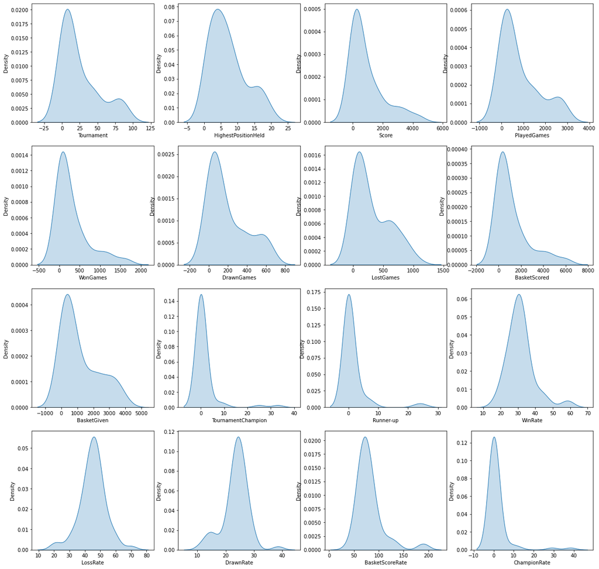

```python
plt.figure(figsize=(20,20))

index = 1
for col in game_uni.columns:
    plt.subplot(4,4,index)
    sns.kdeplot(data=game_uni,x=col,fill=True,palette="crest")
    index += 1
```

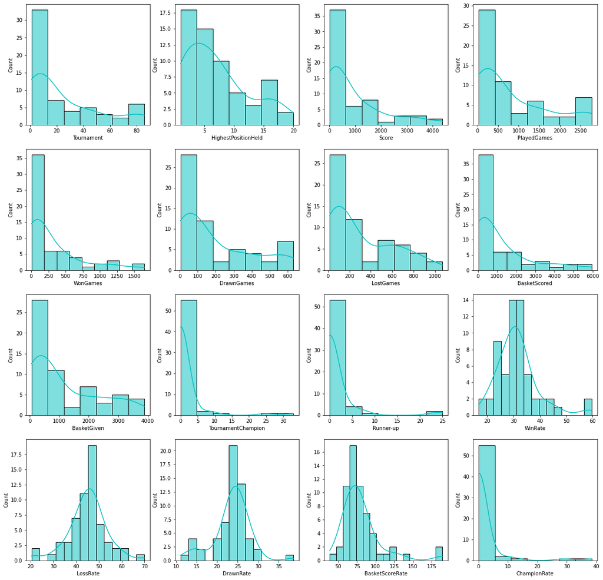

```python
plt.figure(figsize=(20,20))

x = 1
for col in game_uni.columns:
    plt.subplot(4,4,x)
    sns.histplot(data=game_uni,x=col,kde=True,color="c")
    x += 1
```

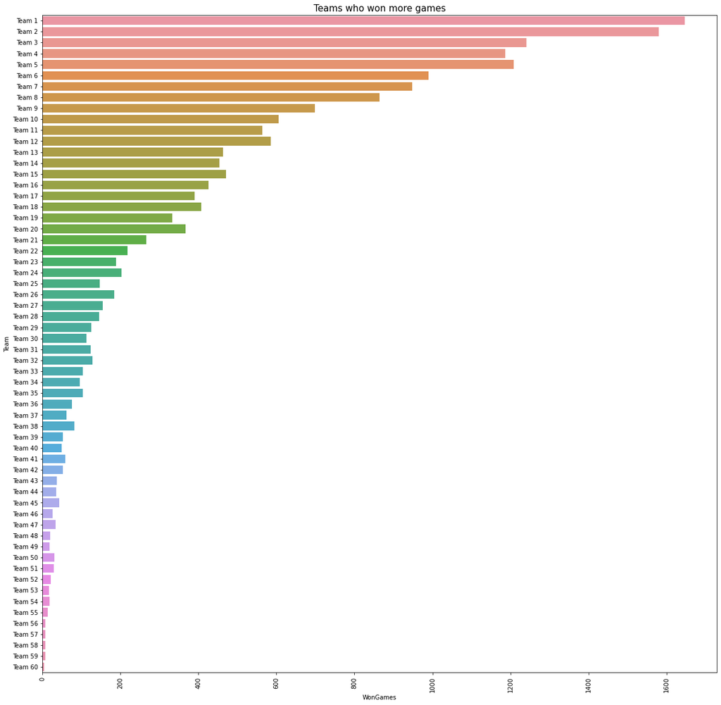

```python
#Bar plot to check Teams who won more games
#import matplotlib.pyplot as plt
#from importlib import reload
#plt=reload(plt)
plt.figure(figsize=(20,20))
game_final.sort_values(by=['WonGames'],ascending=False)
sns.barplot(data=game_final, x='WonGames',y='Team')
plt.xticks(rotation=90)
plt.title("Teams who won more games",size=15)
plt.show()
```

Team1 has won maximum number of games.

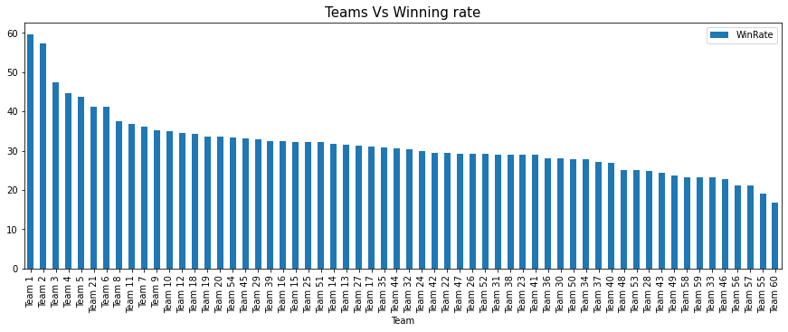

```python
#Bar plot to check teams who have high winning rate
game_final.sort_values(by=['WinRate'],ascending=False).plot(x='Team',y='WinRate',kind='bar',figsize=(15,5))
plt.title("Teams Vs Winning rate", size=15)
```

Team1,Team2, Team3 are the top three teams that have good winning rates.

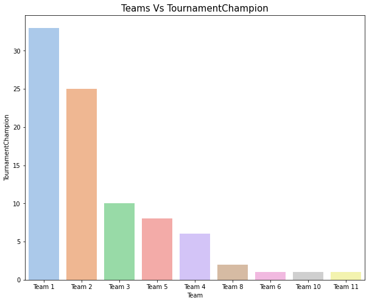

```python
#Bar plot to check teams who have won maximum tournaments
plt.figure(figsize=(10,8))
sns.barplot(x='Team', y='TournamentChampion', data=game_final[game_final['TournamentChampion']>0].sort_values(by=['TournamentChampion'],ascending=False), palette='pastel')  # barplot
plt.title("Teams Vs TournamentChampion", Size=15)
```

Team1, Team2, Team3 are the top three teams to have won maximum tournament championship

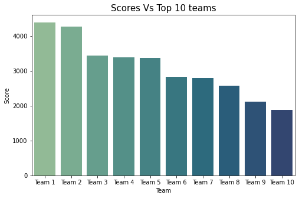

```python
#Bar plot to check top 10 teams who have highest scores
plt.figure(figsize=(8,5))
ax=sns.barplot(x='Team', y='Score', data=game_final.sort_values(by=['Score'],ascending=False).head(10), palette='crest')
plt.title("Scores Vs Top 10 teams", Size=15)
plt.show()
```

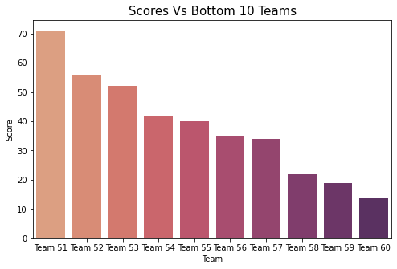

```python
#Bar plot to check bottom 10 teams who have least scores
plt.figure(figsize=(8,5))
ax = sns.barplot(x='Team', y='Score', data=game_final.sort_values(by=['Score'],ascending=False).tail(10), palette='flare')
plt.title("Scores Vs Bottom 10 Teams", Size=15)
plt.show()
```

```python
#TournamentChampion Vs Teams
g = {'Team':lambda x: list(x),
     'Tournament' :lambda x: x.mean()
    }
game_bytourn=game_final[game_final['TournamentChampion']>0].groupby('TournamentChampion').agg(g).reset_index()
game_bytourn.sort_values(by=['TournamentChampion'],ascending=False).head(10)
```

|  | TournamentChampion | Team | Tournament |
| --- | --- | --- | --- |
| 6 | 33 | [Team 1] | 86.000000 |
| 5 | 25 | [Team 2] | 86.000000 |
| 4 | 10 | [Team 3] | 80.000000 |
| 3 | 8 | [Team 5] | 86.000000 |
| 2 | 6 | [Team 4] | 82.000000 |
| 1 | 2 | [Team 8] | 70.000000 |
| 0 | 1 | [Team 6, Team 10, Team 11] | 56.333333 |

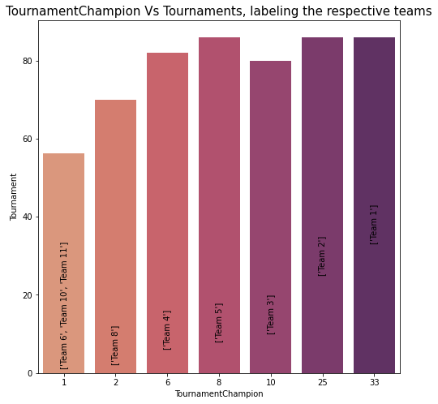

```python
#Bar plot for TournamentChampion Vs Tournaments, labeling the teams who won the Tournament Championship
plt.figure(figsize=(8,8))
ax = sns.barplot(x='TournamentChampion', y='Tournament', data=game_bytourn, palette='flare')  # barplot
plt.title("TournamentChampion Vs Tournaments, labeling the respective teams", Size=15)

for index, row in game_bytourn.iterrows():
    ax.text(row.name,row.TournamentChampion, row.Team, color='black', ha="center", va='bottom', rotation=90)
```

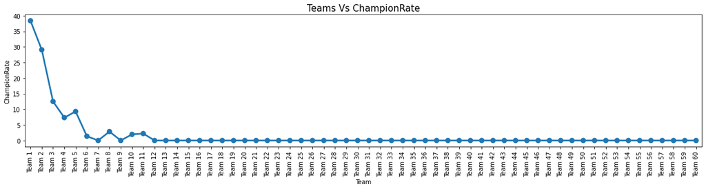

```python
#Pointplot for ChampionRate
plt.figure(figsize=(20,4))
ax=sns.pointplot(data=game_final, x='Team', y='ChampionRate')
plt.xticks(rotation=90)
plt.title("Teams Vs ChampionRate",size=15)
plt.show()
```

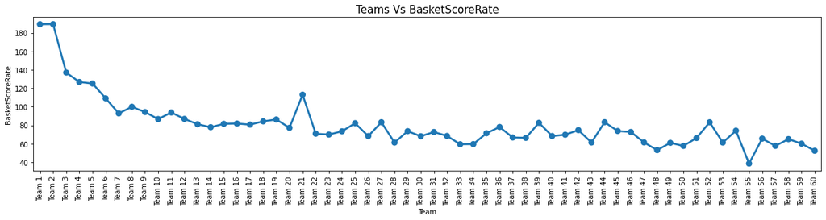

```python
#Pointplot for BasketScoreRate
plt.figure(figsize=(20,4))
ax=sns.pointplot(data=game_final, x='Team', y='BasketScoreRate')
plt.xticks(rotation=90)
plt.title("Teams Vs BasketScoreRate",size=15)
plt.show()
```

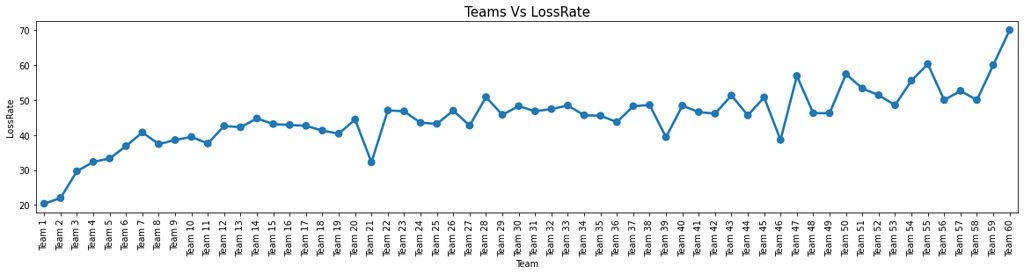

```python
#Pointplot for LossRate
plt.figure(figsize=(20,4))
ax=sns.pointplot(data=game_final, x='Team', y='LossRate')
plt.xticks(rotation=90)
plt.title("Teams Vs LossRate",size=15)
plt.show()
```

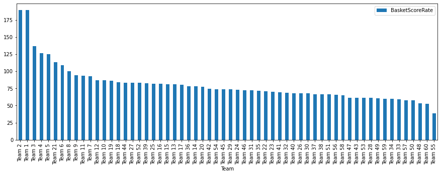

```python
#Bar plot to check teams who have high basketscore rate
game_final.sort_values(by=['BasketScoreRate'],ascending=False).plot(x='Team',y='BasketScoreRate',kind='bar',figsize=(15,5))
```

```python
#Finding Youngest and oldest teams
g = {'Team':lambda x: list(x),
     'TeamLaunch':lambda x: x.count()}
game_byyear=game_final.groupby('TeamLaunchYear').agg(g).reset_index()
game_byyear_head=game_byyear.sort_values(by=['TeamLaunchYear'],ascending=True).head(10)
game_byyear_tail=game_byyear.sort_values(by=['TeamLaunchYear'],ascending=True).tail(10)
game_byyear_head
```

|  | TeamLaunchYear | Team | TeamLaunch |
| --- | --- | --- | --- |
| 0 | 1929 | [Team 1, Team 2, Team 3, Team 5, Team 7, Team ... | 10 |
| 1 | 1930 | [Team 29] | 1 |
| 2 | 1931 | [Team 4] | 1 |
| 3 | 1932 | [Team 10] | 1 |
| 4 | 1933 | [Team 18] | 1 |
| 5 | 1934 | [Team 6] | 1 |
| 6 | 1935 | [Team 16, Team 26] | 2 |
| 7 | 1939 | [Team 9, Team 12] | 2 |
| 8 | 1940 | [Team 28] | 1 |
| 9 | 1941 | [Team 11, Team 22, Team 35] | 3 |

```python
game_byyear_tail
```

|  | TeamLaunchYear | Team | TeamLaunch |
| --- | --- | --- | --- |
| 34 | 1994 | [Team 39] | 1 |
| 35 | 1995 | [Team 49] | 1 |
| 36 | 1996 | [Team 48] | 1 |
| 37 | 1998 | [Team 21] | 1 |
| 38 | 1999 | [Team 43] | 1 |
| 39 | 2004 | [Team 25] | 1 |
| 40 | 2007 | [Team 37] | 1 |
| 41 | 2009 | [Team 57] | 1 |
| 42 | 2014 | [Team 44] | 1 |
| 43 | 2016 | [Team 56] | 1 |

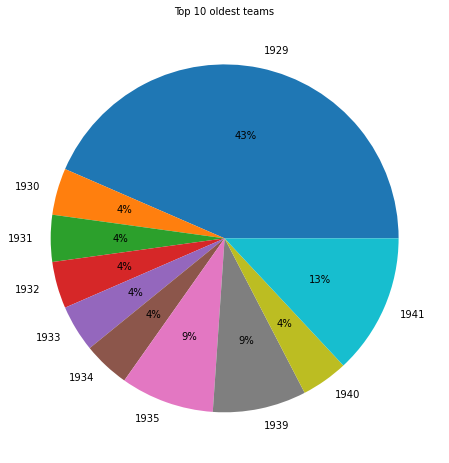

```python
#Among top 10 oldest teams, pie-chart depicting the distribution of teams launched per year
plt.figure(figsize=(8,8))
plt.pie(data=game_byyear_head, labels='TeamLaunchYear', x='TeamLaunch',autopct='%.0f%%')
plt.title("Top 10 oldest teams", size=10)
plt.show()
```

```
    TeamLaunchYear       Team  TeamLaunch
34            1994  [Team 39]           1
35            1995  [Team 49]           1
36            1996  [Team 48]           1
37            1998  [Team 21]           1
38            1999  [Team 43]           1
39            2004  [Team 25]           1
40            2007  [Team 37]           1
41            2009  [Team 57]           1
42            2014  [Team 44]           1
43            2016  [Team 56]           1
```

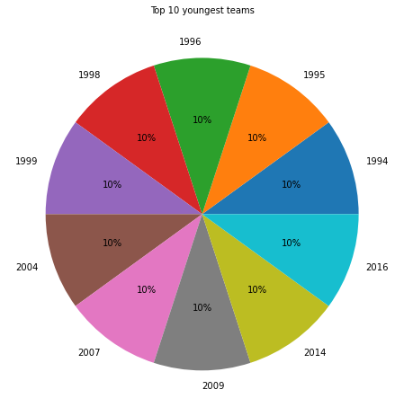

```python
#Among top 10 oldest teams, pie-chart depicting the distribution of teams launched per year
plt.figure(figsize=(8,8))
print(game_byyear_tail)
plt.pie(data=game_byyear_tail, labels='TeamLaunchYear', x='TeamLaunch',autopct='%.0f%%')
plt.title("Top 10 youngest teams", size=10)
plt.show()
```

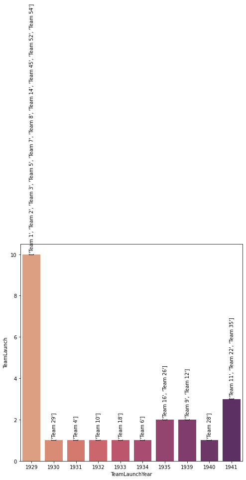

```python
#Bar plot for TeamLaunchYear Vs number of teams launched, labeling the teams who were launched on each year
plt.figure(figsize=(8,8))

ax = sns.barplot(x='TeamLaunchYear', y='TeamLaunch', data=game_byyear.sort_values(by=['TeamLaunchYear'],ascending=True).head(10), palette='flare')  # barplot

for index, row in game_byyear_head.iterrows():
    ax.text(row.name,row.TeamLaunch, row.Team, color='black',va="bottom",ha="center",rotation=90)
```

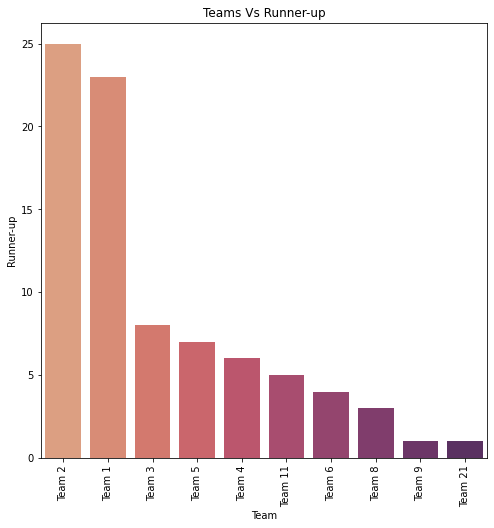

```python
#Barplot on teams who bagged runner-up most frequently
plt.figure(figsize=(8,8))
ax = sns.barplot(x='Team', y='Runner-up', data=game_final.sort_values(by=['Runner-up'],ascending=False).head(10), palette='flare')  # barplot
plt.title("Teams Vs Runner-up")
plt.xticks(rotation=90)
plt.show()
```

Team2 has bagged the runner-up title for most of the times, followed by Team1 and then Team3.

### Multivariate Analysis

```python
#Find correlation among the columns
game_final.corr()
```

|  | Tournament | HighestPositionHeld | Score | PlayedGames | WonGames | DrawnGames | LostGames | BasketScored | BasketGiven | TournamentChampion | Runner-up | WinRate | LossRate | DrawnRate | BasketScoreRate | ChampionRate | TeamLaunchYear |
| --- | --- | --- | --- | --- | --- | --- | --- | --- | --- | --- | --- | --- | --- | --- | --- | --- | --- |
| Tournament | 1.000000 | -0.708002 | 0.981258 | 0.998683 | 0.971749 | 0.989295 | 0.949350 | 0.974867 | 0.987781 | 0.589304 | 0.645924 | 0.819545 | -0.761288 | -0.003360 | 0.807171 | 0.600883 | -0.599166 |
| HighestPositionHeld | -0.708002 | 1.000000 | -0.669215 | -0.711065 | -0.647819 | -0.720248 | -0.726172 | -0.648672 | -0.727323 | -0.304307 | -0.359191 | -0.737345 | 0.661364 | 0.047801 | -0.621888 | -0.314335 | 0.599679 |
| Score | 0.981258 | -0.669215 | 1.000000 | 0.979687 | 0.997232 | 0.958090 | 0.878780 | 0.996634 | 0.943801 | 0.715014 | 0.764819 | 0.877374 | -0.809569 | -0.014233 | 0.890534 | 0.725743 | -0.538542 |
| PlayedGames | 0.998683 | -0.711065 | 0.979687 | 1.000000 | 0.967486 | 0.993972 | 0.955925 | 0.969970 | 0.990020 | 0.575072 | 0.633101 | 0.813167 | -0.767906 | 0.019754 | 0.801266 | 0.586938 | -0.581243 |
| WonGames | 0.971749 | -0.647819 | 0.997232 | 0.967486 | 1.000000 | 0.939416 | 0.851436 | 0.999312 | 0.925745 | 0.752904 | 0.797849 | 0.884266 | -0.802826 | -0.038627 | 0.902900 | 0.762727 | -0.540421 |
| DrawnGames | 0.989295 | -0.720248 | 0.958090 | 0.993972 | 0.939416 | 1.000000 | 0.972786 | 0.942234 | 0.992479 | 0.503378 | 0.566021 | 0.774409 | -0.757453 | 0.068343 | 0.757939 | 0.516512 | -0.570175 |
| LostGames | 0.949350 | -0.726172 | 0.878780 | 0.955925 | 0.851436 | 0.972786 | 1.000000 | 0.857843 | 0.985041 | 0.324025 | 0.391645 | 0.665352 | -0.655034 | 0.065677 | 0.615394 | 0.336750 | -0.591571 |
| BasketScored | 0.974867 | -0.648672 | 0.996634 | 0.969970 | 0.999312 | 0.942234 | 0.857843 | 1.000000 | 0.931079 | 0.743847 | 0.791041 | 0.879110 | -0.795045 | -0.044405 | 0.897185 | 0.753377 | -0.550150 |
| BasketGiven | 0.987781 | -0.727323 | 0.943801 | 0.990020 | 0.925745 | 0.992479 | 0.985041 | 0.931079 | 1.000000 | 0.471618 | 0.533448 | 0.757267 | -0.717077 | 0.021462 | 0.724385 | 0.483896 | -0.608902 |
| TournamentChampion | 0.589304 | -0.304307 | 0.715014 | 0.575072 | 0.752904 | 0.503378 | 0.324025 | 0.743847 | 0.471618 | 1.000000 | 0.971533 | 0.765329 | -0.638634 | -0.139284 | 0.856031 | 0.999453 | -0.286768 |
| Runner-up | 0.645924 | -0.359191 | 0.764819 | 0.633101 | 0.797849 | 0.566021 | 0.391645 | 0.791041 | 0.533448 | 0.971533 | 1.000000 | 0.801226 | -0.677173 | -0.129423 | 0.889186 | 0.973615 | -0.317250 |
| WinRate | 0.819545 | -0.737345 | 0.877374 | 0.813167 | 0.884266 | 0.774409 | 0.665352 | 0.879110 | 0.757267 | 0.765329 | 0.801226 | 1.000000 | -0.851454 | -0.150212 | 0.950214 | 0.772801 | -0.491244 |
| LossRate | -0.761288 | 0.661364 | -0.809569 | -0.767906 | -0.802826 | -0.757453 | -0.655034 | -0.795045 | -0.717077 | -0.638634 | -0.677173 | -0.851454 | 1.000000 | -0.390061 | -0.865967 | -0.646915 | 0.201733 |
| DrawnRate | -0.003360 | 0.047801 | -0.014233 | 0.019754 | -0.038627 | 0.068343 | 0.065677 | -0.044405 | 0.021462 | -0.139284 | -0.129423 | -0.150212 | -0.390061 | 1.000000 | -0.034899 | -0.136748 | 0.478500 |
| BasketScoreRate | 0.807171 | -0.621888 | 0.890534 | 0.801266 | 0.902900 | 0.757939 | 0.615394 | 0.897185 | 0.724385 | 0.856031 | 0.889186 | 0.950214 | -0.865967 | -0.034899 | 1.000000 | 0.861823 | -0.381389 |
| ChampionRate | 0.600883 | -0.314335 | 0.725743 | 0.586938 | 0.762727 | 0.516512 | 0.336750 | 0.753377 | 0.483896 | 0.999453 | 0.973615 | 0.772801 | -0.646915 | -0.136748 | 0.861823 | 1.000000 | -0.294698 |
| TeamLaunchYear | -0.599166 | 0.599679 | -0.538542 | -0.581243 | -0.540421 | -0.570175 | -0.591571 | -0.550150 | -0.608902 | -0.286768 | -0.317250 | -0.491244 | 0.201733 | 0.478500 | -0.381389 | -0.294698 | 1.000000 |

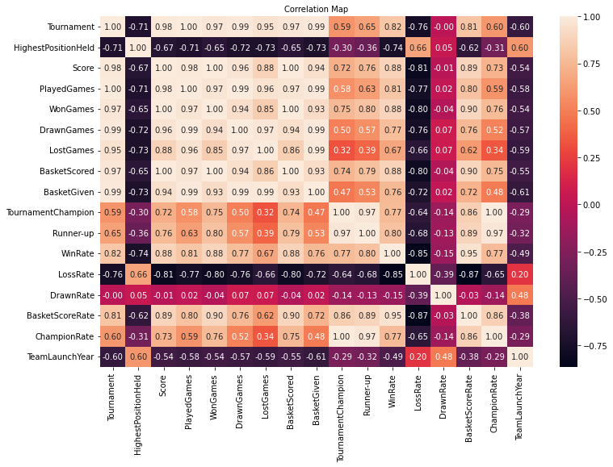

```python
#correlation map
plt.figure(figsize=(12,8))
corr_matrix = game_final.corr(method='pearson')
sns.heatmap(corr_matrix, fmt='.2f',annot=True)
plt.title("Correlation Map", size=10)
plt.show()
```

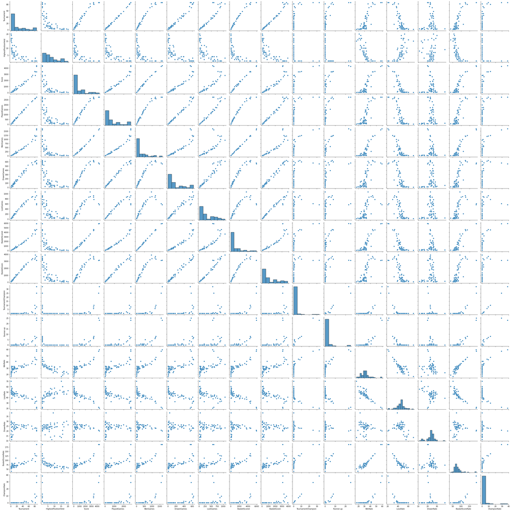

```python
#Pairplot for all numerical fields
plt.figure(figsize=(15,10))
pairplot=sns.pairplot(game_uni)
plt.show()
```

```python
game_final['TeamLaunchAgeCategory'] = pd.qcut(game_final['TeamLaunchYear'], 4, labels=['very_old', 'old', 'new', 'very_new'])
game_final.head(5)
```

|  | Team | Tournament | TeamLaunch | HighestPositionHeld | Score | PlayedGames | WonGames | DrawnGames | LostGames | BasketScored | BasketGiven | TournamentChampion | Runner-up | WinRate | LossRate | DrawnRate | BasketScoreRate | ChampionRate | TeamLaunchYear | TeamLaunchAgeCategory |
| --- | --- | --- | --- | --- | --- | --- | --- | --- | --- | --- | --- | --- | --- | --- | --- | --- | --- | --- | --- | --- |
| 0 | Team 1 | 86 | 1929 | 1 | 4385 | 2762 | 1647 | 552 | 563 | 5947 | 3140 | 33 | 23 | 59.63 | 20.38 | 19.99 | 189.39 | 38.37 | 1929 | very_old |
| 1 | Team 2 | 86 | 1929 | 1 | 4262 | 2762 | 1581 | 573 | 608 | 5900 | 3114 | 25 | 25 | 57.24 | 22.01 | 20.75 | 189.47 | 29.07 | 1929 | very_old |
| 2 | Team 3 | 80 | 1929 | 1 | 3442 | 2614 | 1241 | 598 | 775 | 4534 | 3309 | 10 | 8 | 47.48 | 29.65 | 22.88 | 137.02 | 12.50 | 1929 | very_old |
| 3 | Team 4 | 82 | 1931to32 | 1 | 3386 | 2664 | 1187 | 616 | 861 | 4398 | 3469 | 6 | 6 | 44.56 | 32.32 | 23.12 | 126.78 | 7.32 | 1931 | very_old |
| 4 | Team 5 | 86 | 1929 | 1 | 3368 | 2762 | 1209 | 633 | 920 | 4631 | 3700 | 8 | 7 | 43.77 | 33.31 | 22.92 | 125.16 | 9.30 | 1929 | very_old |

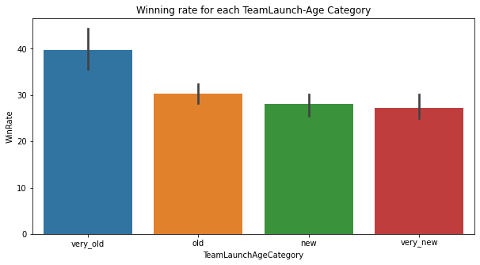

```python
plt.figure(figsize=(10,5))
sns.barplot(data=game_final, x ='TeamLaunchAgeCategory', y='WinRate')
plt.title("Winning rate for each TeamLaunch-Age Category")
```

Very old team have high winning rate compared to other categories.

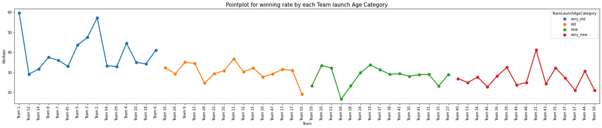

```python
plt.figure(figsize=(30,5))
sns.pointplot(data=game_final.sort_values(['TeamLaunchYear'],ascending=True), x='Team',y='WinRate',hue='TeamLaunchAgeCategory')
plt.xticks(rotation=90)
plt.title("Pointplot for winning rate by each Team launch Age Category",size=15)
plt.show()
```

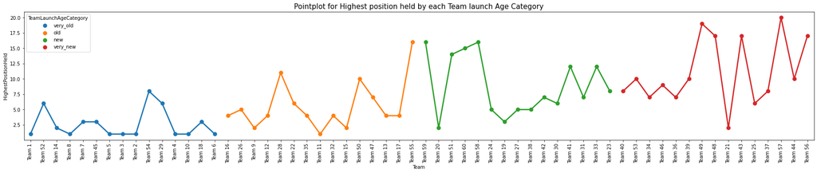

```python
plt.figure(figsize=(30,5))
sns.pointplot(data=game_final.sort_values(['TeamLaunchYear'],ascending=True), x='Team',y='HighestPositionHeld',hue='TeamLaunchAgeCategory')
plt.xticks(rotation=90)
plt.title("Pointplot for Highest position held by each Team launch Age Category",size=15)
plt.show()
```

```python
#Find the best performing team
#Condition used - Team who has maximum winning rate and minimum loss rate
game_final[(game_final.WinRate==game_final.WinRate.max()) & (game_final.LossRate==game_final.LossRate.min())]
```

|  | Team | Tournament | TeamLaunch | HighestPositionHeld | Score | PlayedGames | WonGames | DrawnGames | LostGames | BasketScored | BasketGiven | TournamentChampion | Runner-up | WinRate | LossRate | DrawnRate | BasketScoreRate | ChampionRate | TeamLaunchYear | TeamLaunchAgeCategory |
| --- | --- | --- | --- | --- | --- | --- | --- | --- | --- | --- | --- | --- | --- | --- | --- | --- | --- | --- | --- | --- |
| 0 | Team 1 | 86 | 1929 | 1 | 4385 | 2762 | 1647 | 552 | 563 | 5947 | 3140 | 33 | 23 | 59.63 | 20.38 | 19.99 | 189.39 | 38.37 | 1929 | very_old |

- Team1 is the best performing team in the whole dataset given.

#### It is mentioned that - Some of the older teams are already in contract with competitors. Hence Company X wants to understand which teams they can approach which will be a deal win for them. Let us assume that teams under very_old age category are already in contract with competitors. Let us see which teams are best in the next age categories.

```python
#Teams with more winning rate in non very_old team launch age category
game_final[game_final.TeamLaunchAgeCategory != 'very_old'].sort_values(['WinRate'],ascending=[False]).head(10)
```

|  | Team | Tournament | TeamLaunch | HighestPositionHeld | Score | PlayedGames | WonGames | DrawnGames | LostGames | BasketScored | BasketGiven | TournamentChampion | Runner-up | WinRate | LossRate | DrawnRate | BasketScoreRate | ChampionRate | TeamLaunchYear | TeamLaunchAgeCategory |
| --- | --- | --- | --- | --- | --- | --- | --- | --- | --- | --- | --- | --- | --- | --- | --- | --- | --- | --- | --- | --- |
| 20 | Team 21 | 17 | 1998-99 | 2 | 970 | 646 | 266 | 172 | 208 | 892 | 789 | 0 | 1 | 41.18 | 32.20 | 26.63 | 113.05 | 0.00 | 1998 | very_new |
| 10 | Team 11 | 45 | 1941to42 | 1 | 1814 | 1530 | 563 | 392 | 575 | 2052 | 2188 | 1 | 5 | 36.80 | 37.58 | 25.62 | 93.78 | 2.22 | 1941 | old |
| 8 | Team 9 | 58 | 1939-40 | 2 | 2109 | 1986 | 698 | 522 | 766 | 2683 | 2847 | 0 | 1 | 35.15 | 38.57 | 26.28 | 94.24 | 0.00 | 1939 | old |
| 11 | Team 12 | 51 | 1939-40 | 4 | 1789 | 1698 | 586 | 389 | 723 | 2278 | 2624 | 0 | 0 | 34.51 | 42.58 | 22.91 | 86.81 | 0.00 | 1939 | old |
| 18 | Team 19 | 27 | 1960-61 | 3 | 1148 | 988 | 333 | 256 | 399 | 1182 | 1371 | 0 | 0 | 33.70 | 40.38 | 25.91 | 86.21 | 0.00 | 1960 | new |
| 19 | Team 20 | 33 | 1951-52 | 2 | 1020 | 1096 | 367 | 242 | 487 | 1347 | 1746 | 0 | 1 | 33.49 | 44.43 | 22.08 | 77.15 | 0.00 | 1951 | new |
| 38 | Team 39 | 4 | 1994-95 | 10 | 190 | 160 | 52 | 45 | 63 | 199 | 241 | 0 | 0 | 32.50 | 39.38 | 28.12 | 82.57 | 0.00 | 1994 | very_new |
| 15 | Team 16 | 37 | 1935-36 | 4 | 1351 | 1318 | 426 | 327 | 565 | 1500 | 1834 | 0 | 0 | 32.32 | 42.87 | 24.81 | 81.79 | 0.00 | 1935 | old |
| 14 | Team 15 | 43 | 1944_45 | 2 | 1389 | 1458 | 471 | 358 | 629 | 1753 | 2152 | 0 | 1 | 32.30 | 43.14 | 24.55 | 81.46 | 0.00 | 1944 | old |
| 24 | Team 25 | 12 | 2004to05 | 6 | 553 | 456 | 147 | 112 | 197 | 520 | 633 | 0 | 0 | 32.24 | 43.20 | 24.56 | 82.15 | 0.00 | 2004 | very_new |

- Team21 is the best team with high winning rate in the non-very-old team launch age category. This team falls under very_new team launch age category.
- Followed by Team11 which is from old category and has more played games and won games. Team11 seems to be well experienced and also with good winning rate.

#### Team21 and Team11 can be recommended for company X.

In general,

- In old team launch age category, team11 and team9 can be recommended for comapny x.
- In new team launch age category, team19 and team20 can be recommended for comapny x.
- In very_new team launch age category, team21 and team39 can be recommended for comapny x.

```python
#Top 3 teams who played the most games
game_final.sort_values(['PlayedGames'],ascending=False).head(3)
```

|  | Team | Tournament | TeamLaunch | HighestPositionHeld | Score | PlayedGames | WonGames | DrawnGames | LostGames | BasketScored | BasketGiven | TournamentChampion | Runner-up | WinRate | LossRate | DrawnRate | BasketScoreRate | ChampionRate | TeamLaunchYear | TeamLaunchAgeCategory |
| --- | --- | --- | --- | --- | --- | --- | --- | --- | --- | --- | --- | --- | --- | --- | --- | --- | --- | --- | --- | --- |
| 0 | Team 1 | 86 | 1929 | 1 | 4385 | 2762 | 1647 | 552 | 563 | 5947 | 3140 | 33 | 23 | 59.63 | 20.38 | 19.99 | 189.39 | 38.37 | 1929 | very_old |
| 1 | Team 2 | 86 | 1929 | 1 | 4262 | 2762 | 1581 | 573 | 608 | 5900 | 3114 | 25 | 25 | 57.24 | 22.01 | 20.75 | 189.47 | 29.07 | 1929 | very_old |
| 4 | Team 5 | 86 | 1929 | 1 | 3368 | 2762 | 1209 | 633 | 920 | 4631 | 3700 | 8 | 7 | 43.77 | 33.31 | 22.92 | 125.16 | 9.30 | 1929 | very_old |

Team1, Team2 and Team5 are the top 3 teams who played maximum games.

```python
#Bottom 3 teams with respect to number of games played
game_final.sort_values(['PlayedGames'],ascending=True).head(3)
```

|  | Team | Tournament | TeamLaunch | HighestPositionHeld | Score | PlayedGames | WonGames | DrawnGames | LostGames | BasketScored | BasketGiven | TournamentChampion | Runner-up | WinRate | LossRate | DrawnRate | BasketScoreRate | ChampionRate | TeamLaunchYear | TeamLaunchAgeCategory |
| --- | --- | --- | --- | --- | --- | --- | --- | --- | --- | --- | --- | --- | --- | --- | --- | --- | --- | --- | --- | --- |
| 59 | Team 60 | 1 | 1955-56 | 15 | 14 | 30 | 5 | 4 | 21 | 34 | 65 | 0 | 0 | 16.67 | 70.0 | 13.33 | 52.31 | 0.0 | 1955 | new |
| 57 | Team 58 | 1 | 1956-57 | 16 | 22 | 30 | 7 | 8 | 15 | 37 | 57 | 0 | 0 | 23.33 | 50.0 | 26.67 | 64.91 | 0.0 | 1956 | new |
| 58 | Team 59 | 1 | 1951~52 | 16 | 19 | 30 | 7 | 5 | 18 | 51 | 85 | 0 | 0 | 23.33 | 60.0 | 16.67 | 60.00 | 0.0 | 1951 | new |

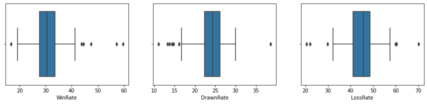

```python
plt.figure(figsize=(15,3))
game_result=game_final[['WinRate','DrawnRate','LossRate']]
x = 1
for col in game_result.columns:
    plt.subplot(1,3,x)
    sns.boxplot(data=game_result,x=col)
    x += 1
```

- There are outliers in all three stats - WinRate, DrawnRate, LossRate.
- The outliers on WinRate says that there are teams which are performing extraordinary well and their winning rate is far beyond other teams.
- The outliers on LossRate says that there are teams which are performing very bad compared to other team.
- The outliers on DrawnRate says that there are teams which had drawn the game many times. If given more practice, these teams may perform very well and improve their win percentage.

### 3. Please include any improvements or suggestions to the association management on quality, quantity, variety, velocity, veracity etc. on the data points collected by the association to perform a better data analysis in future. At-least 1 suggestion for each point. [10 Marks]

#### Quality:

- The given data had incomplete data. For example, Team61 had PlayedGames as 0 but has HighestPositionHeld as 9. The quality of the data can be improved by providing complete/accurate data.
- Team launch year had approximations providing betwene years and was given in various formats. Correct year can be documented in standard year format.

#### Quantity:

- The data was provided only for 61 teams. If we have information about the players who played for each team and their performances, we can see how each player contributed for the team.
- Between year 1980 and 1990, there is only one team launched in 1987. In entire one decade, data was collected for only one team. Similarly there are other decades - 2000, 2010 also have very less number of teams. Collecting as much as data on a regular basis will help improve the analysis.

#### Variety:

- There is no information on team's progression from one tournament to next tournament. If given, we could have examined the team's performance trend. This will give more confidence in recommending the teams to company X.
- Few more information like Turnover percentage, Team Pace, League Pace, League Points Per Possession could have helped to more to understand the team's performance

#### Velocity:

Team's latest information was not collected. Quickly collecting the latest information and keeping the data upto date will help better predictions. Few example below:

- There is no information on team's last played year. What are their scores and winning positions in the recent past?
- Team's all time highest position held was given. Team's latest position, played year, how many times the highest position was held by the team could have given more insights on team's performance.

#### Veracity:

- Between year 1980 and 1990, there is only one team launched in 1987. In entire one decade, data was collected for only one team. Similarly there are other decades - 2000, 2010 also have very less number of teams data. Data is not collected for all the teams accurately and timely. This can be improved.
- Collected data should no have missing details, like team61 record.

# Part C

## PROJECT OBJECTIVE:

Analyse the data of the various companies from the given dataset and perform the tasks that are specified in the below steps. Draw insights from the various attributes that are present in the dataset, plot distributions, state hypotheses and draw conclusions from the dataset.

### STEPS AND TASK [15 Marks]:

#### 1. Read the CSV file.

```python
comp_file=pd.read_csv("CompanyX_EU.csv")
comp_file.head()
```

|  | Startup | Product | Funding | Event | Result | OperatingState |
| --- | --- | --- | --- | --- | --- | --- |
| 0 | 2600Hz | 2600hz.com | NaN | Disrupt SF 2013 | Contestant | Operating |
| 1 | 3DLT | 3dlt.com | $630K | Disrupt NYC 2013 | Contestant | Closed |
| 2 | 3DPrinterOS | 3dprinteros.com | NaN | Disrupt SF 2016 | Contestant | Operating |
| 3 | 3Dprintler | 3dprintler.com | $1M | Disrupt NY 2016 | Audience choice | Operating |
| 4 | 42 Technologies | 42technologies.com | NaN | Disrupt NYC 2013 | Contestant | Operating |

#### 2. Data Exploration: [1 Mark]

##### A. Check the datatypes of each attribute

```python
comp_file.dtypes
```

```
Startup           object
Product           object
Funding           object
Event             object
Result            object
OperatingState    object
dtype: object
```

```python
comp_file.info()
```

```
<class 'pandas.core.frame.DataFrame'>
RangeIndex: 662 entries, 0 to 661
Data columns (total 6 columns):
 #   Column          Non-Null Count  Dtype
---  ------          --------------  -----
 0   Startup         662 non-null    object
 1   Product         656 non-null    object
 2   Funding         448 non-null    object
 3   Event           662 non-null    object
 4   Result          662 non-null    object
 5   OperatingState  662 non-null    object
dtypes: object(6)
memory usage: 31.2+ KB
```

```python
comp_file.describe(include="all")
```

|  | Startup | Product | Funding | Event | Result | OperatingState |
| --- | --- | --- | --- | --- | --- | --- |
| count | 662 | 656 | 448 | 662 | 662 | 662 |
| unique | 662 | 656 | 240 | 26 | 5 | 4 |
| top | 2600Hz | 2600hz.com | $1M | TC50 2008 | Contestant | Operating |
| freq | 1 | 1 | 17 | 52 | 488 | 465 |

```python
comp_file.shape
```

```
(662, 6)
```

##### B. Check for null values in the attributes

```python
comp_file.isna()
```

|  | Startup | Product | Funding | Event | Result | OperatingState |
| --- | --- | --- | --- | --- | --- | --- |
| 0 | False | False | True | False | False | False |
| 1 | False | False | False | False | False | False |
| 2 | False | False | True | False | False | False |
| 3 | False | False | False | False | False | False |
| 4 | False | False | True | False | False | False |
| ... | ... | ... | ... | ... | ... | ... |
| 657 | False | False | False | False | False | False |
| 658 | False | False | False | False | False | False |
| 659 | False | False | False | False | False | False |
| 660 | False | False | False | False | False | False |
| 661 | False | False | False | False | False | False |

662 rows × 6 columns

```python
#number of null values in each column
comp_file.isnull().sum(axis = 0)
```

```
Startup             0
Product             6
Funding           214
Event               0
Result              0
OperatingState      0
dtype: int64
```

#### 3. Data preprocessing & visualisation: [4 Marks]

##### A. Drop the null values. [1 Mark]

```python
comp_cleaned=comp_file.dropna()
```

```python
comp_cleaned.info()
```

```
<class 'pandas.core.frame.DataFrame'>
Int64Index: 446 entries, 1 to 661
Data columns (total 6 columns):
 #   Column          Non-Null Count  Dtype
---  ------          --------------  -----
 0   Startup         446 non-null    object
 1   Product         446 non-null    object
 2   Funding         446 non-null    object
 3   Event           446 non-null    object
 4   Result          446 non-null    object
 5   OperatingState  446 non-null    object
dtypes: object(6)
memory usage: 24.4+ KB
```

```python
comp_cleaned.isnull().sum(axis = 0)
```

```
Startup           0
Product           0
Funding           0
Event             0
Result            0
OperatingState    0
dtype: int64
```

##### B. Convert the ‘Funding’ features to a numerical value.

```python
comp_cleaned.loc[:,'Funds_in_million'] = comp_cleaned['Funding'].apply(lambda x: float(x[1:-1])/1000 if x[-1] == 'K' else (float(x[1:-1])*1000 if x[-1] == 'B' else float(x[1:-1])))
```

```python
comp_cleaned.head()
```

|  | Startup | Product | Funding | Event | Result | OperatingState | Funds_in_million |
| --- | --- | --- | --- | --- | --- | --- | --- |
| 1 | 3DLT | 3dlt.com | $630K | Disrupt NYC 2013 | Contestant | Closed | 0.63 |
| 3 | 3Dprintler | 3dprintler.com | $1M | Disrupt NY 2016 | Audience choice | Operating | 1.00 |
| 5 | 5to1 | 5to1.com | $19.3M | TC50 2009 | Contestant | Acquired | 19.30 |
| 6 | 8 Securities | 8securities.com | $29M | Disrupt Beijing 2011 | Finalist | Operating | 29.00 |
| 10 | AdhereTech | adheretech.com | $1.8M | Hardware Battlefield 2014 | Contestant | Operating | 1.80 |

```python
comp_cleaned.describe()
```

|  | Funds_in_million |
| --- | --- |
| count | 446.000000 |
| mean | 17.241489 |
| std | 90.483710 |
| min | 0.005000 |
| 25% | 0.745250 |
| 50% | 2.200000 |
| 75% | 9.475000 |
| max | 1700.000000 |

##### C. Plot box plot for funds in million. [1 Mark]

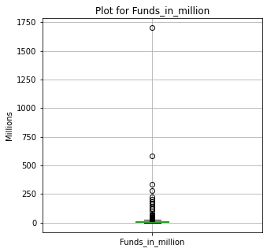

```python
comp_cleaned.boxplot(column="Funds_in_million",return_type='axes',figsize=(5,5))

plt.ylabel('Millions')
plt.title('Plot for Funds_in_million')
```

##### D. Check the number of outliers greater than the upper fence. [1 Mark]

```python
quantile_1=comp_cleaned["Funds_in_million"].quantile(q=0.25)
quantile_2=comp_cleaned["Funds_in_million"].quantile(q=0.50)
quantile_3=comp_cleaned["Funds_in_million"].quantile(q=0.75)
print("Funds_in_million min value = {}".format(comp_cleaned["Funds_in_million"].min()))
print("Funds_in_million quantile_1 = {}".format(quantile_1))
print("Funds_in_million quantile_2 = {}".format(quantile_2))
print("Funds_in_million quantile_3 = {}".format(quantile_3))
print("Funds_in_million max value = {}".format(comp_cleaned["Funds_in_million"].max()))
iqr=comp_cleaned["Funds_in_million"].quantile(0.75) - comp_cleaned["Funds_in_million"].quantile(0.25)
print("Funds_in_million iqr = {}".format(iqr))
upper_fence=quantile_3 + (1.5*iqr)
print("Funds_in_million upper_fence = {}".format(upper_fence))
comp_outlier=comp_cleaned.loc[comp_cleaned["Funds_in_million"] > upper_fence]
print("Answer: Count of outliers greater than upper fence in Funds_in_million: {}".format(comp_outlier["Funds_in_million"].shape[0]))
print("Answer: Below are the records with outliers greater than upper fence in Funds_in_million")
comp_outlier
```

```
Funds_in_million min value = 0.005
Funds_in_million quantile_1 = 0.74525
Funds_in_million quantile_2 = 2.2
Funds_in_million quantile_3 = 9.475
Funds_in_million max value = 1700.0
Funds_in_million iqr = 8.72975
Funds_in_million upper_fence = 22.569625
Answer: Count of outliers greater than upper fence in Funds_in_million: 60
Answer: Below are the records with outliers greater than upper fence in Funds_in_million
```

|  | Startup | Product | Funding | Event | Result | OperatingState | Funds_in_million |
| --- | --- | --- | --- | --- | --- | --- | --- |
| 6 | 8 Securities | 8securities.com | $29M | Disrupt Beijing 2011 | Finalist | Operating | 29.0 |
| 31 | Anyclip | anyclip.com | $24M | TC50 2009 | Finalist | Operating | 24.0 |
| 40 | Artsy | artsy.net | $50.9M | Disrupt NYC 2010 | Contestant | Operating | 50.9 |
| 49 | Badgeville | badgeville.com | $40M | Disrupt SF 2010 | Finalist | Acquired | 40.0 |
| 56 | Betterment | betterment.com | $205M | Disrupt NYC 2010 | Finalist | Operating | 205.0 |
| 108 | Clickable | clickable.com | $32.5M | TC40 2007 | Finalist | Acquired | 32.5 |
| 113 | Cloudflare | cloudflare.com | $182.1M | Disrupt SF 2010 | Runner up | Operating | 182.1 |
| 128 | Credit Sesame | creditsesame.com | $35.4M | Disrupt SF 2010 | Contestant | Operating | 35.4 |
| 130 | CrowdFlower Inc. | crowdflower.com | $38M | TC50 2009 | Contestant | Operating | 38.0 |
| 132 | Cubic Telecom | cubictelecom.com | $37.1M | TC40 2007 | Contestant | Operating | 37.1 |
| 138 | DataSift | datasift.com | $72M | Disrupt SF 2010 | Finalist | Operating | 72.0 |
| 139 | DataXu | dataxu.com | $64M | TC50 2009 | Contestant | Operating | 64.0 |
| 154 | Dropbox | dropbox.com | $1.7B | TC50 2008 | Contestant | Operating | 1700.0 |
| 166 | Enigma | enigma.io | $34.6M | Disrupt NYC 2013 | Winner | Operating | 34.6 |
| 172 | EverythingMe | everything.me | $35.5M | Disrupt NYC 2011 | Contestant | Closed | 35.5 |
| 179 | Famo.us | famo.us | $30.1M | Disrupt SF 2012 | Contestant | Operating | 30.1 |
| 180 | Farmigo | farmigo.com | $26M | Disrupt SF 2011 | Finalist | Operating | 26.0 |
| 188 | Fitbit | fitbit.com | $66M | TC50 2008 | Finalist | Ipo | 66.0 |
| 191 | Flock | flock.com | $28.3M | TC40 2007 | Contestant | Acquired | 28.3 |
| 209 | Getaround | getaround.com | $103M | Disrupt NYC 2011 | Winner | Operating | 103.0 |
| 213 | Gild | gild.com | $25.9M | Disrupt SF 2010 | Contestant | Acquired | 25.9 |
| 215 | Glide | glide.me | $36.5M | Disrupt NYC 2013 | Audience choice | Operating | 36.5 |
| 225 | Grockit | grockit.com | $44.7M | TC50 2008 | Finalist | Acquired | 44.7 |
| 231 | HackerRank | hackerrank.com | $24.2M | Disrupt SF 2012 | Contestant | Operating | 24.2 |
| 271 | Ionic Security | ionicsecurity.com | $122.4M | Disrupt SF 2012 | Contestant | Operating | 122.4 |
| 276 | IZEA | izea.com | $34.9M | Disrupt NYC 2010 | Contestant | Ipo | 34.9 |
| 279 | Jiff | jiff.com | $67.8M | Disrupt SF 2011 | Contestant | Acquired | 67.8 |
| 282 | Kaltura | kaltura.com | $166.1M | TC40 2007 | Audience choice | Operating | 166.1 |
| 302 | Layer | layer.com | $42.1M | Disrupt SF 2013 | Winner | Operating | 42.1 |
| 305 | LearnVest | learnvest.com | $69M | TC50 2009 | Contestant | Acquired | 69.0 |
| 313 | LiveIntent | liveintent.com | $65.1M | Disrupt NYC 2010 | Audience choice | Operating | 65.1 |
| 325 | Lystable | lystable.com | $25.1M | Disrupt London 2015 | Finalist | Operating | 25.1 |
| 346 | Mint | mint.com | $31.8M | TC40 2007 | Winner | Acquired | 31.8 |
| 389 | OrderWithMe | orderwithme.com | $37M | Disrupt Beijing 2011 | Winner | Operating | 37.0 |
| 393 | Osmo | playosmo.com | $38.5M | Disrupt SF 2013 | Contestant | Operating | 38.5 |
| 394 | Ossia | ossia.com | $25.5M | Disrupt SF 2013 | Runner up | Operating | 25.5 |
| 398 | Owlet Baby Care | owletcare.com | $24M | Hardware Battlefield 2014 | Runner up | Operating | 24.0 |
| 427 | Postmates | postmates.com | $278M | Disrupt SF 2011 | Contestant | Operating | 278.0 |
| 432 | Prism Skylabs | prism.com | $24M | Disrupt SF 2011 | Runner up | Operating | 24.0 |
| 435 | PubMatic | pubmatic.com | $63M | TC40 2007 | Contestant | Operating | 63.0 |
| 460 | Roadie | roadie.com | $25M | Disrupt NYC 2014 | Audience choice | Operating | 25.0 |
| 471 | SeatGeek | seatgeek.com | $160M | TC50 2009 | Contestant | Operating | 160.0 |
| 546 | StyleSeat | styleseat.com | $40M | Disrupt NYC 2011 | Contestant | Operating | 40.0 |
| 555 | Symphony Commerce | symphonycommerce.com | $47.4M | Disrupt NYC 2011 | Contestant | Operating | 47.4 |
| 560 | Talkdesk | talkdesk.com | $24.5M | Disrupt NYC 2012 | Contestant | Operating | 24.5 |
| 581 | TouchPal | touchpal.com | $25M | Disrupt Beijing 2011 | Finalist | Operating | 25.0 |
| 593 | TrueCar | truecar.com | $332.4M | TC50 2008 | Contestant | Ipo | 332.4 |
| 598 | UberConference | uberconference.com | $35M | Disrupt NYC 2012 | Winner | Operating | 35.0 |
| 606 | Upwork | upwork.com | $168.8M | TC50 2009 | Audience choice | Operating | 168.8 |
| 615 | VideoSurf | videosurf.com | $28M | TC50 2008 | Contestant | Acquired | 28.0 |
| 625 | Voxy | voxy.com | $30.8M | Disrupt SF 2010 | Contestant | Operating | 30.8 |
| 643 | Xobni | yahoo.com | $41.8M | TC40 2007 | Contestant | Acquired | 41.8 |
| 644 | Yammer | yammer.com | $142M | TC50 2008 | Winner | Acquired | 142.0 |
| 647 | Yext | yext.com | $117.8M | TC50 2009 | Contestant | Ipo | 117.8 |
| 649 | YouNow | younow.com | $26M | Disrupt SF 2011 | Contestant | Operating | 26.0 |
| 650 | YourMechanic | yourmechanic.com | $28M | Disrupt SF 2012 | Winner | Operating | 28.0 |
| 654 | ZEFR | zefr.com | $62.1M | Disrupt NYC 2010 | Contestant | Operating | 62.1 |
| 656 | Zenefits | zenefits.com | $583.6M | Disrupt NYC 2013 | Finalist | Operating | 583.6 |
| 659 | Zocdoc | zocdoc.com | $223M | TC40 2007 | Contestant | Operating | 223.0 |
| 661 | Zumper | zumper.com | $31.5M | Disrupt SF 2012 | Finalist | Operating | 31.5 |

###### For further analysis on this data, let us remove the 60 outlier company records which are funded excessively compared to other companies.

```python
comp_cleaned.drop(comp_cleaned[comp_cleaned.Funds_in_million > upper_fence].index, inplace = True)
comp_cleaned.shape
```

```
(386, 7)
```

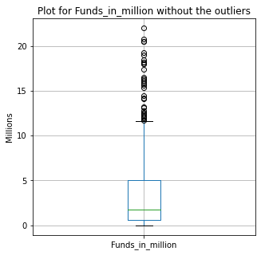

```python
# ow we can again prepare the box plot for Funds_in_million withoit the outliers
comp_cleaned.boxplot(column="Funds_in_million",return_type='axes',figsize=(5,5))

plt.ylabel('Millions')
plt.title('Plot for Funds_in_million without the outliers')
```

##### E. Check frequency of the OperatingState features classes. [1 Mark]

```python
comp_cleaned['OperatingState'].value_counts()
```

```
Operating    275
Closed        56
Acquired      55
Name: OperatingState, dtype: int64
```

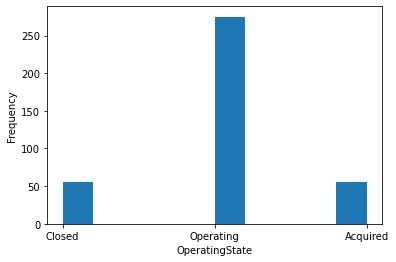

```python
plt.hist(comp_cleaned['OperatingState'])
plt.xlabel('OperatingState')   # label the x-axis
plt.ylabel('Frequency')   # label the y-axis
plt.show()
```

#### 4. Statistical Analysis: [10 Marks]

##### A. Is there any significant difference between Funds raised by companies that are still operating vs companies that closed down? [1 Mark]

```
Funds_in_million    AxesSubplot(0.1,0.15;0.8x0.75)
dtype: object
```

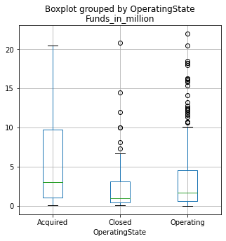

```python
comp_cleaned.boxplot(column="Funds_in_million",by="OperatingState",return_type='axes',figsize=(5,5))
```

```python
comp_operating=comp_cleaned.loc[comp_cleaned['OperatingState'] == 'Operating']
comp_closed=comp_cleaned.loc[comp_cleaned['OperatingState'] == 'Closed']
print("comp_operating shape :{}".format(comp_operating.shape))
print("comp_closed shape :{}".format(comp_closed.shape))
```

```
comp_operating shape :(275, 7)
comp_closed shape :(56, 7)
```

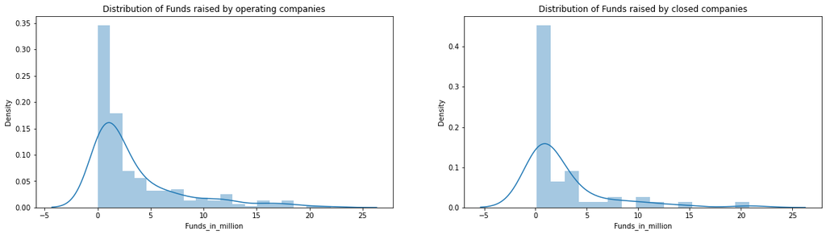

```python
fig, axes = plt.subplots(1, 2,figsize=(20,5))
sns.distplot(comp_operating['Funds_in_million'], ax= axes[0])
sns.distplot(comp_closed['Funds_in_million'], ax= axes[1])

axes[0].set_title('Distribution of Funds raised by operating companies')
axes[1].set_title('Distribution of Funds raised by closed companies')
```

- From the distplots above for the funds raised by companies that are still operating Vs closed , the distributions seems to be similar.
- However, to prove if there is a significant difference between the 2 groups - funds raised by operating companies Vs fund raised by closed companies, we need to do hypothesis test to compare the differences in means of the two samples.
- Since the distributions are not normal and the sample size is > 30 , we can use 2 sample t-test or z-test in this case.

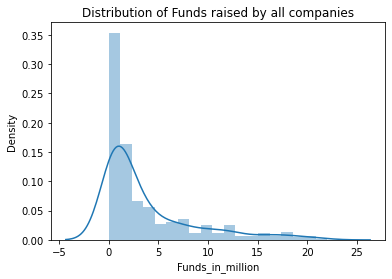

```python
#Distribution of Funds raised by all companies
sns.distplot(comp_cleaned.Funds_in_million)
plt.title('Distribution of Funds raised by all companies')
plt.show()
```

#### B. Write the null hypothesis and alternative hypothesis. [1 Mark]

Null Hypothesis - H0 : There is no significant difference between the means of the two samples i.e μ1 = μ2

Alternate Hypothesis - Ha : There is significant difference between the means of the two samples i.e μ1 != μ2

##### C. Test for significance and conclusion [1 Mark]

```python
from scipy.stats import ttest_ind
from statsmodels.stats.weightstats import ztest

sample1=comp_operating['Funds_in_million']
sample2=comp_closed['Funds_in_million']
test_statistic, p_value = ttest_ind(sample1, sample2)
print("test_statistic = {}".format(test_statistic))
print("p_value = {}".format(p_value))

alpha=0.05
print("significance level considered = {}".format(alpha))


if p_value <= alpha:
    print("Answer: p-value {0} < {1} (alpha), hence the difference is significant and we reject the Null hypothesis".format(round(p_value,3),alpha))
else:
    print("Answer: p-value {0} > {1} (alpha), hence the difference is not significant and we fail to reject the Null hypothesis".format(round(p_value,3),alpha))

#ztest_statistic, z_p_value = ztest(sample1, sample2)
#print("From z-test, test_statistic = {} and p_value ={}".format(ztest_statistic,z_p_value))
```

```
test_statistic = 1.3039132895334589
p_value = 0.1931747168826862
significance level considered = 0.05
Answer: p-value 0.193 > 0.05 (alpha), hence the difference is not significant and we fail to reject the Null hypothesis
```

###### Conclusion:

From the above hypothesis test, there is no evidence to prove that the companies which raised more funds are successful or vice-versa

##### D. Make a copy of the original data frame. [1 Mark]

```python
comp_copy=comp_file.copy()
comp_copy.shape
```

```
(662, 6)
```

##### E. Check frequency distribution of Result variables. [1 Mark]

```python
comp_copy['Result'].value_counts()
```

```
Contestant         488
Finalist            84
Audience choice     41
Winner              26
Runner up           23
Name: Result, dtype: int64
```

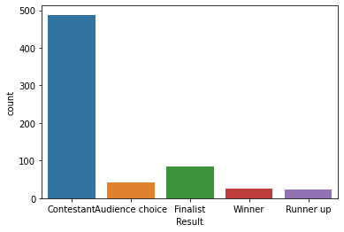

```python
sns.countplot(comp_copy['Result'])
```

##### F. Calculate percentage of winners that are still operating and percentage of contestants that are still operating [1 Mark]

```python
winners=comp_copy.loc[comp_copy['Result']!='Contestant']
winners_count=winners.shape[0]
print("count of winners = {}".format(winners_count))
contestants=comp_copy.loc[comp_copy['Result']=='Contestant']
contestants_count=contestants.shape[0]
print("count of contestants = {}".format(contestants_count))

winners_operating=winners.loc[winners['OperatingState']=='Operating'].shape[0]
print("count of winners that are operating = {}".format(winners_operating))
contestants_operating=contestants.loc[contestants['OperatingState']=='Operating'].shape[0]
print("count of contestants that are operating = {}".format(contestants_operating))

print("Answer: percentage of winners that are still operating = {}".format(winners_operating/winners_count))
print("Answer: percentage of contestants that are still operating = {}".format(contestants_operating/contestants_count))
```

```
count of winners = 174
count of contestants = 488
count of winners that are operating = 133
count of contestants that are operating = 332
Answer: percentage of winners that are still operating = 0.764367816091954
Answer: percentage of contestants that are still operating = 0.680327868852459
```

##### G. Write your hypothesis comparing the proportion of companies that are operating between winners and contestants: [2 Mark]

Null hypothesis H0: The proportion of operating companies in winners category is same as that of the operating companies in contestants category.

Alternative hypothesis (Ha): The proportion of operating companies in winners category is significantly different from that of the operating companies in contestants category.

##### H. Test for significance and conclusion [1 Mark]

```python
from statsmodels.stats.proportion import proportions_ztest

test_statistic, p_value = proportions_ztest([winners_operating,contestants_operating], [winners_count,contestants_count])
print("test_statistic = {}".format(test_statistic))
print("p_value = {}".format(p_value))

alpha=0.05
print("significance level considered = {}".format(alpha))

if p_value <= alpha:
    print("Answer: p-value {0} < {1} (alpha), hence the difference is significant and we reject the Null hypothesis".format(round(p_value,3),alpha))
else:
    print("Answer: p-value {0} > {1} (alpha), hence the difference is not significant and we fail to reject the Null hypothesis".format(round(p_value,3),alpha))
```

```
test_statistic = 2.0818033900737642
p_value = 0.037360431984547006
significance level considered = 0.05
Answer: p-value 0.037 < 0.05 (alpha), hence the difference is significant and we reject the Null hypothesis
```

###### Conclusion:

From the above hypothesis test, winners in the Startup Battlefield have proven to be more operational than the companies that just came out as contestants.

##### I. Select only the Event that has ‘disrupt’ keyword from 2013 onwards. [1 Mark]

```python
comp_disrupt_2013=comp_copy.loc[comp_copy.Event.apply(lambda x: 'disrupt' in x.lower() and int(x[-4:])>=2013)]
print("Filtered df size: {}".format(comp_disrupt_2013.shape))
comp_disrupt_2013['Event'].value_counts()
print("Answer: Count of Event that has ‘disrupt’ keyword from 2013 onwards = {}".format(comp_disrupt_2013.shape[0]))
comp_disrupt_2013
```

```
Filtered df size: (276, 6)
Answer: Count of Event that has ‘disrupt’ keyword from 2013 onwards = 276
```

|  | Startup | Product | Funding | Event | Result | OperatingState |
| --- | --- | --- | --- | --- | --- | --- |
| 0 | 2600Hz | 2600hz.com | NaN | Disrupt SF 2013 | Contestant | Operating |
| 1 | 3DLT | 3dlt.com | $630K | Disrupt NYC 2013 | Contestant | Closed |
| 2 | 3DPrinterOS | 3dprinteros.com | NaN | Disrupt SF 2016 | Contestant | Operating |
| 3 | 3Dprintler | 3dprintler.com | $1M | Disrupt NY 2016 | Audience choice | Operating |
| 4 | 42 Technologies | 42technologies.com | NaN | Disrupt NYC 2013 | Contestant | Operating |
| ... | ... | ... | ... | ... | ... | ... |
| 646 | YayPay Inc | yaypay.com | $900K | Disrupt London 2015 | Contestant | Operating |
| 648 | YOOBIC | yoobic.com | NaN | Disrupt London 2015 | Finalist | Operating |
| 653 | ZAP! | zapreklam.com/ | NaN | Disrupt EU 2014 | Audience choice | Operating |
| 656 | Zenefits | zenefits.com | $583.6M | Disrupt NYC 2013 | Finalist | Operating |
| 660 | Zula | zulaapp.com | $3.4M | Disrupt SF 2013 | Audience choice | Operating |

276 rows × 6 columns